# 02_Analysis

### Biomass

Rosette biomass

```r
# dry rosette biomass
Ros_lm_21 <- do_lmer(Dat_2021_RosSeed$l10_DryRosG, data = Dat_2021_RosSeed)
```

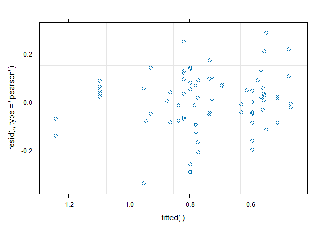

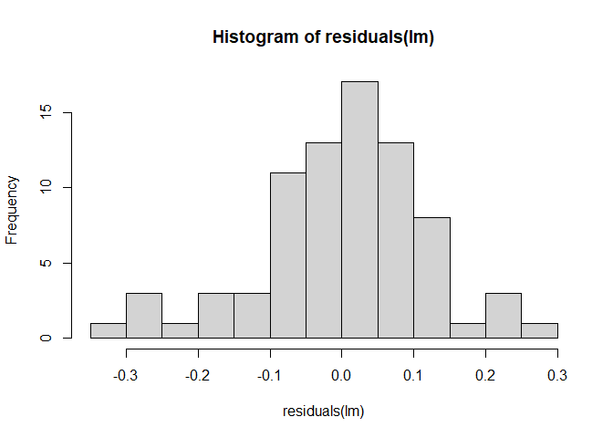

```
## [1] "the number of complete cases is 78"
```

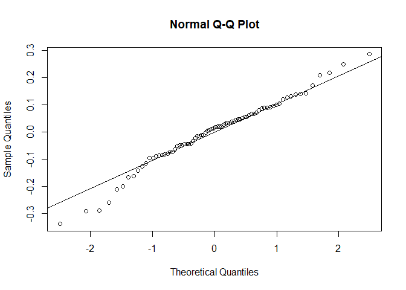

```
## Linear mixed model fit by REML. t-tests use Satterthwaite's method [
## lmerModLmerTest]
## Formula: trait ~ Treatment * Population + (1 | Population:Line)
##    Data: data
##
## REML criterion at convergence: -47.3
##
## Scaled residuals:
##     Min      1Q  Median      3Q     Max
## -2.5359 -0.5265  0.1214  0.5232  2.1438
##
## Random effects:
##  Groups          Name        Variance Std.Dev.
##  Population:Line (Intercept) 0.01680  0.1296
##  Residual                    0.01776  0.1333
## Number of obs: 78, groups:  Population:Line, 17
##
## Fixed effects:
##                        Estimate Std. Error       df t value Pr(>|t|)
## (Intercept)            -0.74501    0.03715 14.37456 -20.055 6.51e-12 ***
## Treatment1              0.13100    0.01561 59.02427   8.391 1.19e-11 ***
## Population1            -0.06748    0.03715 14.37456  -1.817   0.0902 .
## Treatment1:Population1  0.01812    0.01561 59.02427   1.161   0.2504
## ---
## Signif. codes:  0 '***' 0.001 '**' 0.01 '*' 0.05 '.' 0.1 ' ' 1
##
## Correlation of Fixed Effects:
##             (Intr) Trtmn1 Ppltn1
## Treatment1  0.013
## Population1 0.298  0.007
## Trtmnt1:Pp1 0.007  0.228  0.013
```

```
## Computing profile confidence intervals ...
```

```
##                              2.5 %       97.5 %
## .sig01                  0.07386968  0.189917764
## .sigma                  0.11083111  0.158522631
## (Intercept)            -0.81715844 -0.672259722
## Treatment1              0.10061728  0.161829206
## Population1            -0.13970327  0.005181918
## Treatment1:Population1 -0.01225074  0.048967576
```

```r
Ros_anov_21 <- do_anov(Ros_lm_21)
```

```
## Type III Analysis of Variance Table with Satterthwaite's method
##                       Sum Sq Mean Sq NumDF  DenDF F value    Pr(>F)
## Treatment            1.25047 1.25047     1 59.024 70.4102 1.193e-11 ***
## Population           0.05861 0.05861     1 14.375  3.3001   0.09018 .
## Treatment:Population 0.02393 0.02393     1 59.024  1.3472   0.25045
## ---
## Signif. codes:  0 '***' 0.001 '**' 0.01 '*' 0.05 '.' 0.1 ' ' 1
```

```r
Ros_anov_21$trait <- "l10_DryRosG"
Ros_emmeans_21 <- get_table_bt(Ros_lm_21)
Ros_means_21 <- as.data.frame(Ros_emmeans_21)
Ros_pairs_21 <- as.data.frame(pairs(Ros_emmeans_21))
Ros_pairs_21$trait <- "l10_DryRosG"
#no interaction

## check how it compares to the sqr transformed
#Ros_lm_21SR <- do_lmer(Dat_2021_TwoTrt$SQR_DryRosG)
#Ros_anov_21SR <- do_anov(Ros_lm_21SR)
#Ros_anov_21SR$trait <- "SQR_DryRosG"
#Ros_means_21SR <- get_table_bt(Ros_lm_21SR)
## commented out b/c no difference in signficance levels.
```

Reproductive biomass

```r
# dry reproductive biomass
Repro_lm_21 <- do_lmer(Dat_2021_most$l10_DryReproG)
```

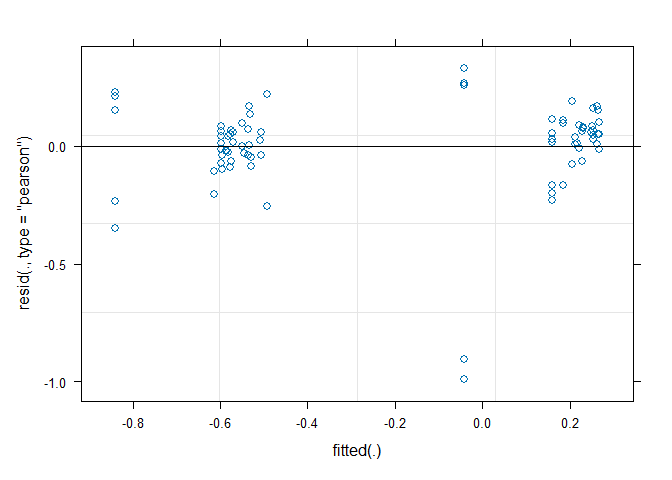

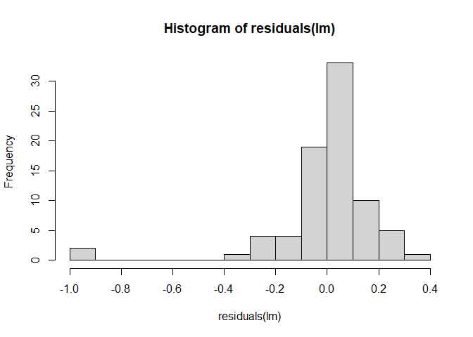

```
## [1] "the number of complete cases is 79"
```

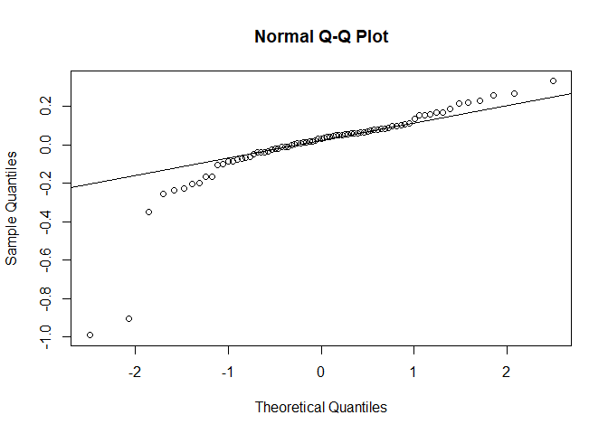

```
## Linear mixed model fit by REML. t-tests use Satterthwaite's method [
## lmerModLmerTest]
## Formula: trait ~ Treatment * Population + (1 | Population:Line)
##    Data: data
##
## REML criterion at convergence: 8.2
##
## Scaled residuals:
##     Min      1Q  Median      3Q     Max
## -4.6767 -0.1819  0.1435  0.3939  1.5645
##
## Random effects:
##  Groups          Name        Variance Std.Dev.
##  Population:Line (Intercept) 0.01103  0.1050
##  Residual                    0.04480  0.2117
## Number of obs: 79, groups:  Population:Line, 18
##
## Fixed effects:
##                        Estimate Std. Error       df t value Pr(>|t|)
## (Intercept)            -0.17223    0.03731 21.70484  -4.616 0.000138 ***
## Treatment1              0.38919    0.02466 66.01976  15.783  < 2e-16 ***
## Population1             0.01689    0.03731 21.70484   0.453 0.655360
## Treatment1:Population1 -0.01002    0.02466 66.01976  -0.406 0.685883
## ---
## Signif. codes:  0 '***' 0.001 '**' 0.01 '*' 0.05 '.' 0.1 ' ' 1
##
## Correlation of Fixed Effects:
##             (Intr) Trtmn1 Ppltn1
## Treatment1  0.017
## Population1 0.318  0.005
## Trtmnt1:Pp1 0.005  0.237  0.017
```

```
## Computing profile confidence intervals ...
```

```
##                              2.5 %      97.5 %
## .sig01                  0.04731759  0.16429751
## .sigma                  0.17685599  0.24770523
## (Intercept)            -0.24402778 -0.09776066
## Treatment1              0.34116689  0.43719945
## Population1            -0.05617211  0.08905537
## Treatment1:Population1 -0.05800443  0.03802872
```

```r
Repro_anov_21 <- do_anov(Repro_lm_21)
```

```
## Type III Analysis of Variance Table with Satterthwaite's method
##                       Sum Sq Mean Sq NumDF  DenDF  F value Pr(>F)
## Treatment            11.1616 11.1616     1 66.020 249.1152 <2e-16 ***
## Population            0.0092  0.0092     1 21.705   0.2048 0.6554
## Treatment:Population  0.0074  0.0074     1 66.020   0.1650 0.6859
## ---
## Signif. codes:  0 '***' 0.001 '**' 0.01 '*' 0.05 '.' 0.1 ' ' 1
```

```r
Repro_anov_21$trait <- "l10_DryReproG"
Repro_emmeans_21 <- get_table_bt(Repro_lm_21)
Repro_means_21 <- as.data.frame(Repro_emmeans_21)
Repro_pairs_21 <- as.data.frame(pairs(Repro_emmeans_21))
Repro_pairs_21$trait <- "l10_DryReproG"
```

Above ground biomass allocation (repro/ros)

```r
# reproductive biomass divided by rosette biomass (i.e., above ground biomass allocation)
RR_lm_21 <- do_lmer(Dat_2021_RosSeed$l10_R_to_R, data = Dat_2021_RosSeed)
```

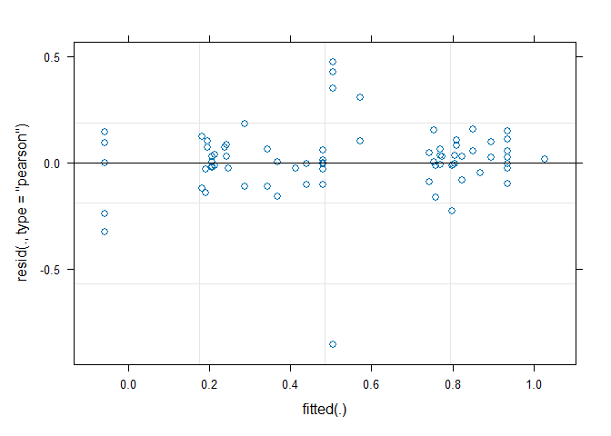

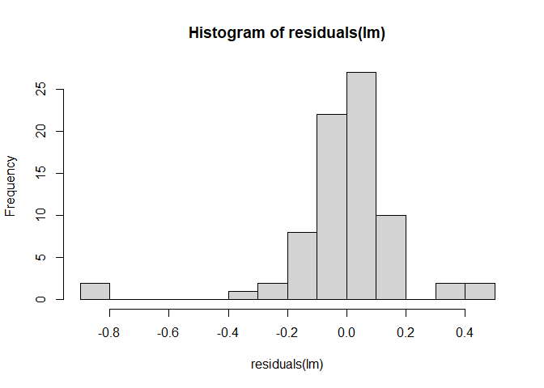

```
## [1] "the number of complete cases is 76"
```

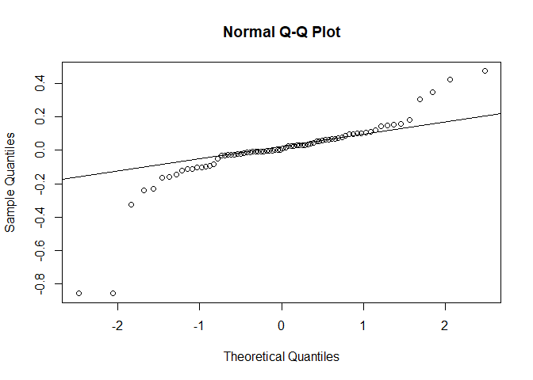

```
## Linear mixed model fit by REML. t-tests use Satterthwaite's method [
## lmerModLmerTest]
## Formula: trait ~ Treatment * Population + (1 | Population:Line)
##    Data: data
##
## REML criterion at convergence: 7.3
##
## Scaled residuals:
##     Min      1Q  Median      3Q     Max
## -4.1385 -0.1348  0.0410  0.3435  2.2887
##
## Random effects:
##  Groups          Name        Variance Std.Dev.
##  Population:Line (Intercept) 0.01375  0.1172
##  Residual                    0.04294  0.2072
## Number of obs: 76, groups:  Population:Line, 17
##
## Fixed effects:
##                        Estimate Std. Error       df t value Pr(>|t|)
## (Intercept)             0.57054    0.03981 18.17345  14.332 2.39e-11 ***
## Treatment1              0.25426    0.02445 61.66757  10.400 3.42e-15 ***
## Population1             0.09357    0.03981 18.17345   2.350   0.0302 *
## Treatment1:Population1 -0.02680    0.02445 61.66757  -1.096   0.2772
## ---
## Signif. codes:  0 '***' 0.001 '**' 0.01 '*' 0.05 '.' 0.1 ' ' 1
##
## Correlation of Fixed Effects:
##             (Intr) Trtmn1 Ppltn1
## Treatment1   0.024
## Population1  0.287 -0.002
## Trtmnt1:Pp1 -0.002  0.207  0.024
```

```
## Computing profile confidence intervals ...
```

```
##                              2.5 %     97.5 %
## .sig01                  0.05421645 0.18284179
## .sigma                  0.17230848 0.24415288
## (Intercept)             0.49368377 0.64881049
## Treatment1              0.20630377 0.30169924
## Population1             0.01497859 0.17026665
## Treatment1:Population1 -0.07464127 0.02072354
```

```r
RR_anov_21 <- do_anov(RR_lm_21)
```

```
## Type III Analysis of Variance Table with Satterthwaite's method
##                      Sum Sq Mean Sq NumDF  DenDF  F value    Pr(>F)
## Treatment            4.6445  4.6445     1 61.668 108.1645 3.417e-15 ***
## Population           0.2372  0.2372     1 18.173   5.5241   0.03024 *
## Treatment:Population 0.0516  0.0516     1 61.668   1.2021   0.27716
## ---
## Signif. codes:  0 '***' 0.001 '**' 0.01 '*' 0.05 '.' 0.1 ' ' 1
```

```r
RR_anov_21$trait <- "l10_Repro_to_Ros"
RR_emmeans_21 <- get_table_bt(RR_lm_21)
RR_means_21 <- as.data.frame(RR_emmeans_21)
RR_pairs_21 <- as.data.frame(pairs(RR_emmeans_21))
RR_pairs_21$trait <- "l10_Repro_to_Ros"
```

### Fitness

Fruit Count: (9/20/2024) using BL’s fruit counts

```r
# number fruits on plant
fruit_lm_21 <- do_lmer(Dat_2021_fitness$FruitCount_BL, data = Dat_2021_fitness)
```

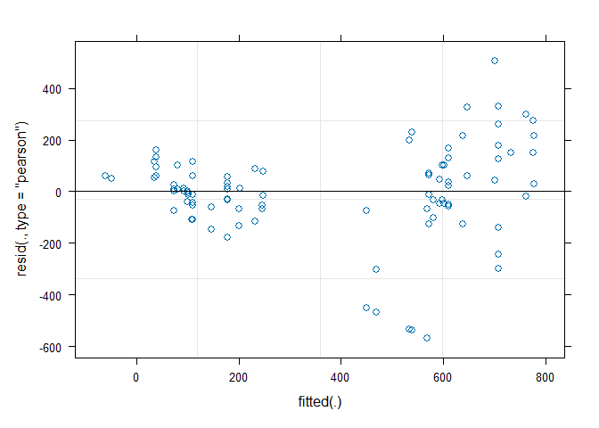

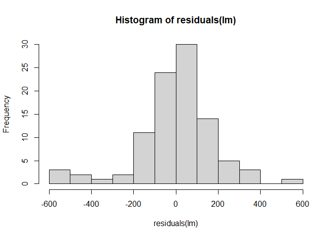

```
## [1] "the number of complete cases is 96"
```

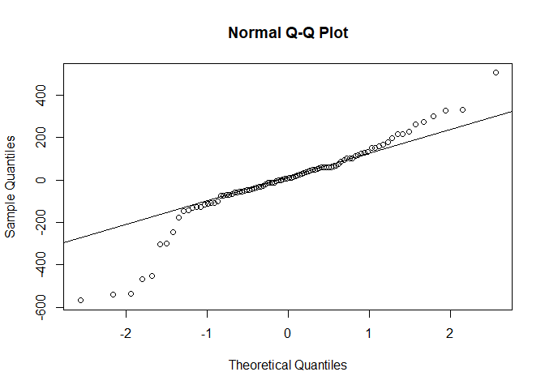

```
## Linear mixed model fit by REML. t-tests use Satterthwaite's method [
## lmerModLmerTest]
## Formula: trait ~ Treatment * Population + (1 | Population:Line)
##    Data: data
##
## REML criterion at convergence: 1263.3
##
## Scaled residuals:
##      Min       1Q   Median       3Q      Max
## -2.95586 -0.32149  0.04401  0.46782  2.63198
##
## Random effects:
##  Groups          Name        Variance Std.Dev.
##  Population:Line (Intercept) 11931    109.2
##  Residual                    36911    192.1
## Number of obs: 96, groups:  Population:Line, 21
##
## Fixed effects:
##                        Estimate Std. Error      df t value Pr(>|t|)
## (Intercept)             376.023     32.365  17.041  11.618  1.6e-09 ***
## Treatment1              257.257     19.887  71.888  12.936  < 2e-16 ***
## Population1              37.728     32.365  17.041   1.166    0.260
## Treatment1:Population1    7.543     19.887  71.888   0.379    0.706
## ---
## Signif. codes:  0 '***' 0.001 '**' 0.01 '*' 0.05 '.' 0.1 ' ' 1
##
## Correlation of Fixed Effects:
##             (Intr) Trtmn1 Ppltn1
## Treatment1  0.000
## Population1 0.239  0.000
## Trtmnt1:Pp1 0.000  0.167  0.000
```

```
## Computing profile confidence intervals ...
```

```
##                            2.5 %    97.5 %
## .sig01                  29.98821 169.56497
## .sigma                 162.77760 225.24820
## (Intercept)            312.86468 439.33735
## Treatment1             218.25449 296.25980
## Population1            -25.49054 100.97883
## Treatment1:Population1 -31.45980  46.54551
```

```r
fruit_anov_21 <- do_anov(fruit_lm_21)
```

```
## Type III Analysis of Variance Table with Satterthwaite's method
##                       Sum Sq Mean Sq NumDF  DenDF  F value Pr(>F)
## Treatment            6176916 6176916     1 71.888 167.3450 <2e-16 ***
## Population             50158   50158     1 17.041   1.3589 0.2598
## Treatment:Population    5310    5310     1 71.888   0.1439 0.7056
## ---
## Signif. codes:  0 '***' 0.001 '**' 0.01 '*' 0.05 '.' 0.1 ' ' 1
```

```r
fruit_anov_21$trait <- "FruitNum"
fruit_emmeans_21 <- get_table(fruit_lm_21)
fruit_means_21 <- as.data.frame(fruit_emmeans_21)
fruit_pairs_21 <- as.data.frame(pairs(fruit_emmeans_21))
fruit_pairs_21$trait <- "FruitNum"

geno_fruits <- as.data.frame(get_geno_table(Dat_2021_fitness$FruitCount_BL, data = Dat_2021_fitness))
geno_fruits$trait <- "FruitNum"
```

Code to see if a hurdle model changes results since there is a pattern of zero inflation. Not evaluated because not used in the final manuscript.

```r
# try a hurdle model
library(pscl)
mod.hurdle <- hurdle(FruitCount_BL ~ Treatment * Population  , data = Dat_2021_TwoTrt, dist = "poisson", zero.dist = "binomial")
summary(mod.hurdle)
hist(residuals(mod.hurdle), breaks = 15) # decent
plot(fitted(mod.hurdle), residuals(mod.hurdle, type = "pearson", scaled = TRUE)) # this looks very similar


mod.zeroinf <- zeroinfl(FruitCount_BL ~ Treatment * Population  , data = Dat_2021_TwoTrt, dist = "poisson")
summary(mod.zeroinf)

#remove zeros from my initial model
mod.nozero <- lmer(FruitCount_BL ~ Treatment * Population + (1|Population:Line) , data = Dat_2021_TwoTrt[Dat_2021_TwoTrt$FruitCount_BL >0, ],contrasts = list(Treatment=contr.sum, Population = contr.sum))
summary(mod.nozero)
hist(residuals(mod.nozero), breaks = 15) # this is more normal
plot(fitted(mod.nozero), residuals(mod.nozero, type = "pearson", scaled = TRUE)) # this looks very similar

# try to get random component back in there
library(glmmTMB)
mod.zeroinf2 <- glmmTMB(FruitCount_BL ~ Treatment * Population + (1|Population:Line), data = Dat_2021_TwoTrt, ziformula = ~Treatment * Population, family = poisson)
summary(mod.zeroinf2)
mod.poisson <- glmmTMB(FruitCount_BL ~ Treatment * Population + (1|Population:Line), data = Dat_2021_TwoTrt, ziformula = ~0, family = poisson)
summary(mod.poisson)
hist(residuals(mod.poisson), breaks = 15) # okay
plot(fitted(mod.poisson), residuals(mod.poisson, type = "pearson"))
plot(fitted(fruit_lm_21), residuals(fruit_lm_21, type = "pearson"))
# okay, so if I fit a poisson model is really where the changes happen, not for adding in the zero inflated component


# get emmeans from the poisson
mod.poisson_emmeans <- get_table(mod.poisson)
mod.poisson_means <- as.data.frame(mod.poisson_emmeans)
mod.poisson_pairs <- as.data.frame(pairs(mod.poisson_emmeans))
mod.poisson_pairs$trait <- "FruitNumP_Pois"

# tester fig
ggplot(data = mod.poisson_means, aes(x = Treatment, y = rate)) +
  geom_point(aes(col=Population, shape = Population), size = 2, position = position_dodge(width = 0.3), show.legend = TRUE) +
  geom_errorbar(aes(ymin=asymp.LCL, ymax = asymp.UCL, col = Population), width = 0.1, size = 0.8, position = position_dodge(width = 0.3), show.legend = TRUE)+
  geom_line(aes(group = Population, col = Population), size = 1, position = position_dodge(width = 0.3))+
  labs(y="Fruit Count Poisson Model (rate)",
      x="Treatment")+
  scale_color_manual(name = "Population",
                     labels = c("IT", "SW"),
                     values = c("#CC79A7", "#009E73"))+
  scale_x_discrete(expand = c(0.6,0))



# zero inflated poisson
mod.zeroinf2_emmeans <- get_table(mod.zeroinf2)
mod.zeroinf2_means <- as.data.frame(mod.zeroinf2_emmeans)
mod.zeroinf2_pairs <- as.data.frame(pairs(mod.zeroinf2_emmeans))
mod.zeroinf2_pairs$trait <- "FruitNumP_PoisZI"

# tester fig
ggplot(data = mod.zeroinf2_means, aes(x = Treatment, y = rate)) +
  geom_point(aes(col=Population, shape = Population), size = 2, position = position_dodge(width = 0.3), show.legend = TRUE) +
  geom_errorbar(aes(ymin=asymp.LCL, ymax = asymp.UCL, col = Population), width = 0.1, size = 0.8, position = position_dodge(width = 0.3), show.legend = TRUE)+
  geom_line(aes(group = Population, col = Population), size = 1, position = position_dodge(width = 0.3))+
  labs(y="Fruit Count Poisson ZI Model (rate)",
      x="Treatment")+
  scale_color_manual(name = "Population",
                     labels = c("IT", "SW"),
                     values = c("#CC79A7", "#009E73"))+
  scale_x_discrete(expand = c(0.6,0))
```

Average weight of a seed (collected seed weight / count of collected seeds)

```r
# weight of collected seeds - take weight divided by number of seeds counted
AvSeedWt_lm_21 <- do_lmer(Dat_2021_RosSeed$AvgSeedWt, data = Dat_2021_RosSeed)
```

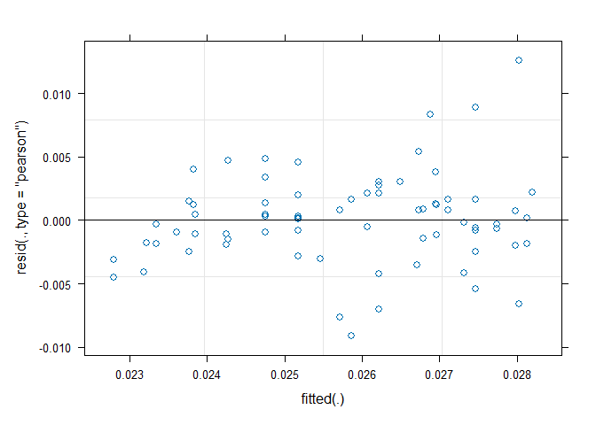

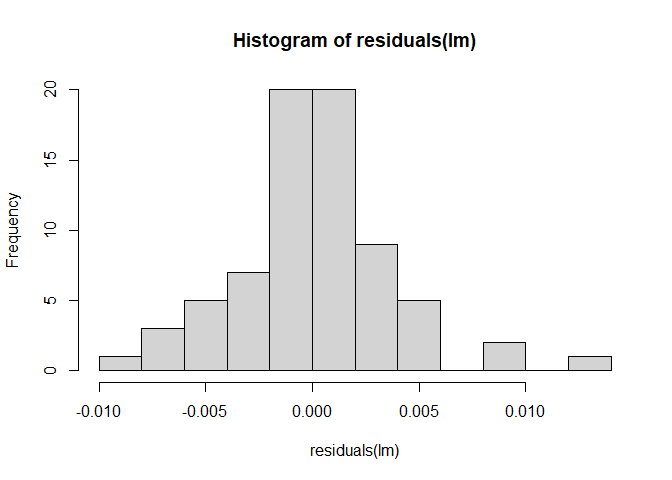

```
## [1] "the number of complete cases is 73"
```

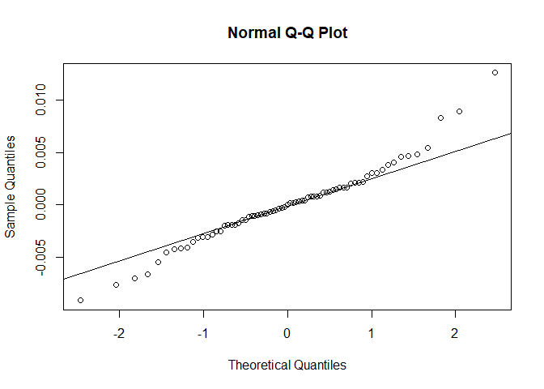

```
## Linear mixed model fit by REML. t-tests use Satterthwaite's method [
## lmerModLmerTest]
## Formula: trait ~ Treatment * Population + (1 | Population:Line)
##    Data: data
##
## REML criterion at convergence: -551.9
##
## Scaled residuals:
##     Min      1Q  Median      3Q     Max
## -2.4048 -0.4961  0.0173  0.4292  3.3214
##
## Random effects:
##  Groups          Name        Variance  Std.Dev.
##  Population:Line (Intercept) 1.263e-06 0.001124
##  Residual                    1.438e-05 0.003792
## Number of obs: 73, groups:  Population:Line, 17
##
## Fixed effects:
##                          Estimate Std. Error         df t value Pr(>|t|)
## (Intercept)             0.0253818  0.0005503 12.1506018  46.120 5.11e-15 ***
## Treatment1              0.0004183  0.0004523 57.3785741   0.925   0.3590
## Population1            -0.0015478  0.0005503 12.1506018  -2.813   0.0155 *
## Treatment1:Population1 -0.0002055  0.0004523 57.3785741  -0.454   0.6513
## ---
## Signif. codes:  0 '***' 0.001 '**' 0.01 '*' 0.05 '.' 0.1 ' ' 1
##
## Correlation of Fixed Effects:
##             (Intr) Trtmn1 Ppltn1
## Treatment1  0.002
## Population1 0.248  0.015
## Trtmnt1:Pp1 0.015  0.176  0.002
```

```
## Computing profile confidence intervals ...
```

```
##                                2.5 %        97.5 %
## .sig01                  0.0000000000  0.0023730180
## .sigma                  0.0031371184  0.0045067432
## (Intercept)             0.0242385892  0.0264418195
## Treatment1             -0.0004524536  0.0013279371
## Population1            -0.0027036835 -0.0004780427
## Treatment1:Population1 -0.0010829591  0.0006900802
```

```r
AvSeedWt_anov_21 <- do_anov(AvSeedWt_lm_21)
```

```
## Type III Analysis of Variance Table with Satterthwaite's method
##                          Sum Sq    Mean Sq NumDF  DenDF F value  Pr(>F)
## Treatment            1.2297e-05 1.2297e-05     1 57.379  0.8551 0.35900
## Population           1.1376e-04 1.1376e-04     1 12.151  7.9103 0.01551 *
## Treatment:Population 2.9690e-06 2.9690e-06     1 57.379  0.2065 0.65126
## ---
## Signif. codes:  0 '***' 0.001 '**' 0.01 '*' 0.05 '.' 0.1 ' ' 1
```

```r
AvSeedWt_anov_21$trait <- "Average Seed Wt"
AvSeedWt_emmeans_21 <- get_table(AvSeedWt_lm_21)
AvSeedWt_means_21 <- as.data.frame(AvSeedWt_emmeans_21)
AvSeedWt_pairs_21 <- as.data.frame(pairs(AvSeedWt_emmeans_21))
AvSeedWt_pairs_21$trait <- "Average Seed Wt"
```

average Seed number per fruit -

```r
# number seeds from collected fruits
seeds_lm_21 <- do_lmer(Dat_2021_RosSeed$l10_AvgSeedNum, data = Dat_2021_RosSeed)
```

```
## boundary (singular) fit: see help('isSingular')
```

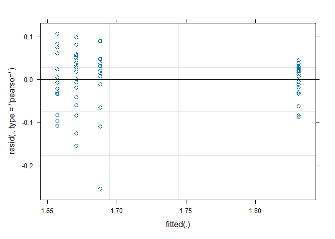

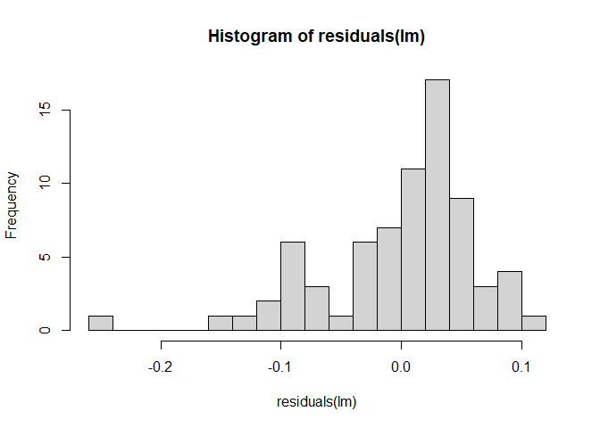

```
## [1] "the number of complete cases is 73"
```

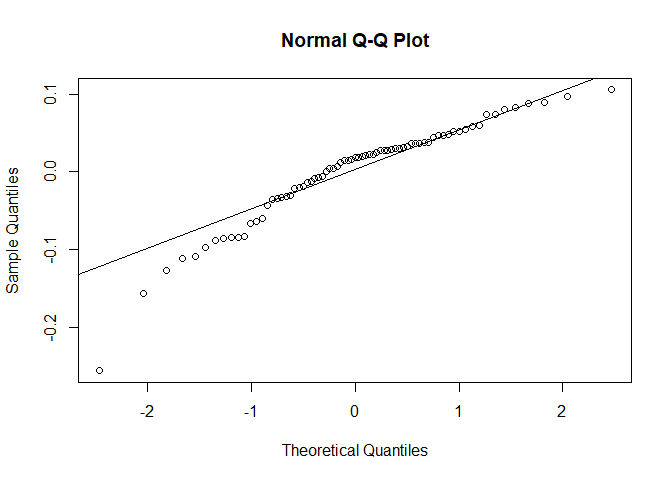

```
## Linear mixed model fit by REML. t-tests use Satterthwaite's method [
## lmerModLmerTest]
## Formula: trait ~ Treatment * Population + (1 | Population:Line)
##    Data: data
##
## REML criterion at convergence: -162.7
##
## Scaled residuals:
##     Min      1Q  Median      3Q     Max
## -3.8849 -0.4721  0.2738  0.5661  1.5998
##
## Random effects:
##  Groups          Name        Variance Std.Dev.
##  Population:Line (Intercept) 0.000000 0.00000
##  Residual                    0.004324 0.06576
## Number of obs: 73, groups:  Population:Line, 17
##
## Fixed effects:
##                         Estimate Std. Error        df t value Pr(>|t|)
## (Intercept)             1.712066   0.007823 69.000000 218.861  < 2e-16 ***
## Treatment1              0.047864   0.007823 69.000000   6.119 5.04e-08 ***
## Population1            -0.039149   0.007823 69.000000  -5.005 4.10e-06 ***
## Treatment1:Population1 -0.032337   0.007823 69.000000  -4.134 9.88e-05 ***
## ---
## Signif. codes:  0 '***' 0.001 '**' 0.01 '*' 0.05 '.' 0.1 ' ' 1
##
## Correlation of Fixed Effects:
##             (Intr) Trtmn1 Ppltn1
## Treatment1  -0.010
## Population1  0.178  0.010
## Trtmnt1:Pp1  0.010  0.178 -0.010
## optimizer (nloptwrap) convergence code: 0 (OK)
## boundary (singular) fit: see help('isSingular')
```

```
## Computing profile confidence intervals ...
```

```
##                              2.5 %      97.5 %
## .sig01                  0.00000000  0.02255498
## .sigma                  0.05481452  0.07589265
## (Intercept)             1.69696239  1.72720033
## Treatment1              0.03276006  0.06296870
## Population1            -0.05425284 -0.02405215
## Treatment1:Population1 -0.04744082 -0.01723219
```

```r
seeds_anov_21 <- do_anov(seeds_lm_21)
```

```
## Type III Analysis of Variance Table with Satterthwaite's method
##                        Sum Sq  Mean Sq NumDF DenDF F value    Pr(>F)
## Treatment            0.161903 0.161903     1    69  37.439 5.041e-08 ***
## Population           0.108314 0.108314     1    69  25.047 4.099e-06 ***
## Treatment:Population 0.073895 0.073895     1    69  17.088 9.884e-05 ***
## ---
## Signif. codes:  0 '***' 0.001 '**' 0.01 '*' 0.05 '.' 0.1 ' ' 1
```

```r
seeds_anov_21$trait <- "l10_Average Seeds per Fruit"
seeds_emmeans_21 <- get_table_bt(seeds_lm_21)
seeds_means_21 <- as.data.frame(seeds_emmeans_21)
seeds_pairs_21 <- as.data.frame(pairs(seeds_emmeans_21))
seeds_pairs_21$trait <- "l10_Average Seeds per Fruit"
# why are residuals so odd? because population explains 0 variance.

geno_seeds <- as.data.frame(get_geno_table_bt(Dat_2021_RosSeed$l10_AvgSeedNum, data = Dat_2021_RosSeed))
geno_seeds$trait <- "l10_seeds per fruit"

## test if SeedCounter matters
#seeds_lm <- lmer(l10_AvgSeedNum ~ Treatment * Population + (1|Population:Line) + (1|SeedCounter), data = Dat_2021_TwoTrt, #contrasts = list(Treatment=contr.sum, Population = contr.sum))
#plot(fitted(seeds_lm), residuals(seeds_lm, type = "pearson", scaled = TRUE),
#       col = c("red", "blue")[as.numeric(Dat_2021_TwoTrt$Population)[complete.cases(Dat_2021_TwoTrt$l10_AvgSeedNum)]],
#       pch = c(16, 15, 17)[as.numeric(Dat_2021_TwoTrt$Treatment)[complete.cases(Dat_2021_TwoTrt$l10_AvgSeedNum)]])
#summary(seeds_lm)
#anova(seeds_lm)
#
## when including seed counter, it does explain some variance (0.0001) but there is more residual (0.0004) and population still explains nothing. The significance levels don't change, and the effect sizes don't really change either though not the standard error and df are different for each predictor
## not going to include in the model.
#
## see if the nesting is doing something unintended. if LineID was the random variable, does anything change?
#Dat_2021_TwoTrt$Line.ID <- as.factor(paste0(Dat_2021_TwoTrt$Population, Dat_2021_TwoTrt$Line))
#seeds_lm2 <- lmer(l10_AvgSeedNum ~ Treatment * Population + (1|Line.ID), data = Dat_2021_TwoTrt, contrasts = #list(Treatment=contr.sum, Population = contr.sum))
#plot(fitted(seeds_lm2), residuals(seeds_lm2, type = "pearson", scaled = TRUE),
#       col = c("red", "blue")[as.numeric(Dat_2021_TwoTrt$Population)[complete.cases(Dat_2021_TwoTrt$l10_AvgSeedNum)]],
#       pch = c(16, 15, 17)[as.numeric(Dat_2021_TwoTrt$Treatment)[complete.cases(Dat_2021_TwoTrt$l10_AvgSeedNum)]])
#summary(seeds_lm2)
#anova(seeds_lm2)
#
## no difference, as expected if the model was functioning as expected. All testing code is commented out and no changes were made to the model.
```

Bonus question about a trade off - are seed weight and seeds per fruit negatively correlated?

```r
# this includes unequal genotype representation because
# overall
cor.test(Dat_2021_RosSeed$AvgSeedNum, Dat_2021_RosSeed$AvgSeedWt)
```

```
##
##  Pearson's product-moment correlation
##
## data:  Dat_2021_RosSeed$AvgSeedNum and Dat_2021_RosSeed$AvgSeedWt
## t = 0.35031, df = 71, p-value = 0.7271
## alternative hypothesis: true correlation is not equal to 0
## 95 percent confidence interval:
##  -0.1903483  0.2690343
## sample estimates:
##        cor
## 0.04153806
```

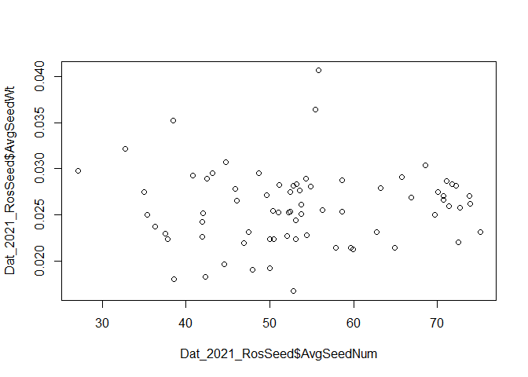

```r
plot(Dat_2021_RosSeed$AvgSeedNum, Dat_2021_RosSeed$AvgSeedWt)
```

```r
# just in SW
cor.test(Dat_2021_RosSeed[Dat_2021_RosSeed$Population == "RODA", ]$AvgSeedNum, Dat_2021_RosSeed[Dat_2021_RosSeed$Population == "RODA", ]$AvgSeedWt)
```

```
##
##  Pearson's product-moment correlation
##
## data:  Dat_2021_RosSeed[Dat_2021_RosSeed$Population == "RODA", ]$AvgSeedNum and Dat_2021_RosSeed[Dat_2021_RosSeed$Population == "RODA", ]$AvgSeedWt
## t = -0.69184, df = 41, p-value = 0.4929
## alternative hypothesis: true correlation is not equal to 0
## 95 percent confidence interval:
##  -0.3950217  0.1993530
## sample estimates:
##        cor
## -0.1074228
```

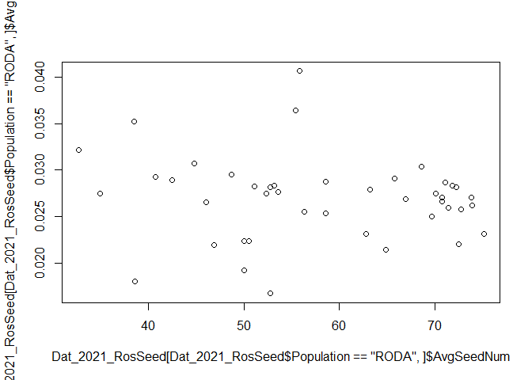

```r
plot(Dat_2021_RosSeed[Dat_2021_RosSeed$Population == "RODA", ]$AvgSeedNum, Dat_2021_RosSeed[Dat_2021_RosSeed$Population == "RODA", ]$AvgSeedWt)
```

```r
# just in IT
cor.test(Dat_2021_RosSeed[Dat_2021_RosSeed$Population == "BELM", ]$AvgSeedNum, Dat_2021_RosSeed[Dat_2021_RosSeed$Population == "BELM", ]$AvgSeedWt)
```

```
##
##  Pearson's product-moment correlation
##
## data:  Dat_2021_RosSeed[Dat_2021_RosSeed$Population == "BELM", ]$AvgSeedNum and Dat_2021_RosSeed[Dat_2021_RosSeed$Population == "BELM", ]$AvgSeedWt
## t = -0.74383, df = 28, p-value = 0.4632
## alternative hypothesis: true correlation is not equal to 0
## 95 percent confidence interval:
##  -0.4756188  0.2327391
## sample estimates:
##       cor
## -0.139202
```

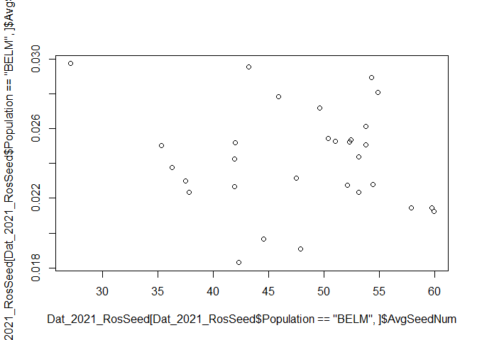

```r
plot(Dat_2021_RosSeed[Dat_2021_RosSeed$Population == "BELM", ]$AvgSeedNum, Dat_2021_RosSeed[Dat_2021_RosSeed$Population == "BELM", ]$AvgSeedWt)
```

```r
# just cur?
cor.test(Dat_2021_RosSeed[Dat_2021_RosSeed$Treatment == "Current", ]$AvgSeedNum, Dat_2021_RosSeed[Dat_2021_RosSeed$Treatment == "Current", ]$AvgSeedWt)
```

```
##
##  Pearson's product-moment correlation
##
## data:  Dat_2021_RosSeed[Dat_2021_RosSeed$Treatment == "Current", ]$AvgSeedNum and Dat_2021_RosSeed[Dat_2021_RosSeed$Treatment == "Current", ]$AvgSeedWt
## t = 0.18098, df = 35, p-value = 0.8574
## alternative hypothesis: true correlation is not equal to 0
## 95 percent confidence interval:
##  -0.2963785  0.3511172
## sample estimates:
##        cor
## 0.03057688
```

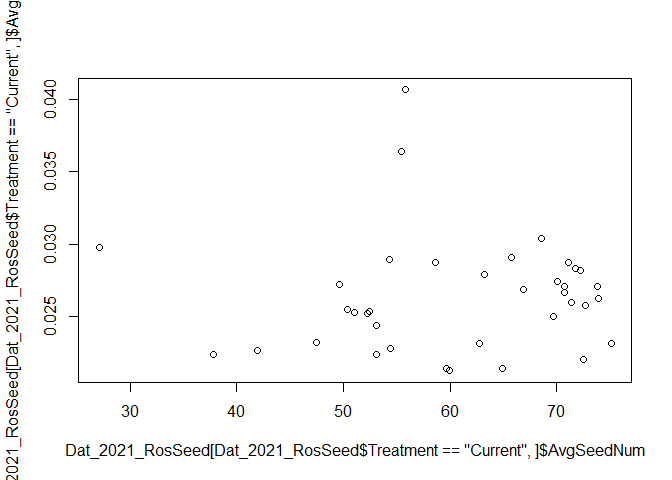

```r
plot(Dat_2021_RosSeed[Dat_2021_RosSeed$Treatment == "Current", ]$AvgSeedNum, Dat_2021_RosSeed[Dat_2021_RosSeed$Treatment == "Current", ]$AvgSeedWt)
```

```r
# just fut?
cor.test(Dat_2021_RosSeed[Dat_2021_RosSeed$Treatment == "Future", ]$AvgSeedNum, Dat_2021_RosSeed[Dat_2021_RosSeed$Treatment == "Future", ]$AvgSeedWt)
```

```
##
##  Pearson's product-moment correlation
##
## data:  Dat_2021_RosSeed[Dat_2021_RosSeed$Treatment == "Future", ]$AvgSeedNum and Dat_2021_RosSeed[Dat_2021_RosSeed$Treatment == "Future", ]$AvgSeedWt
## t = -0.90399, df = 34, p-value = 0.3724
## alternative hypothesis: true correlation is not equal to 0
## 95 percent confidence interval:
##  -0.4586536  0.1846253
## sample estimates:
##        cor
## -0.1532031
```

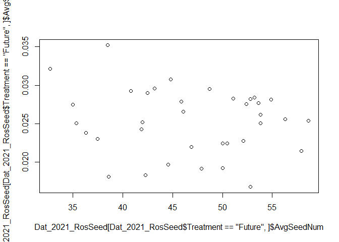

```r
plot(Dat_2021_RosSeed[Dat_2021_RosSeed$Treatment == "Future", ]$AvgSeedNum, Dat_2021_RosSeed[Dat_2021_RosSeed$Treatment == "Future", ]$AvgSeedWt)
```

Total Fitness

```r
# total fitness
fitness_lm_21 <- do_lmer(Dat_2021_fitness$fitness, data = Dat_2021_fitness)
```

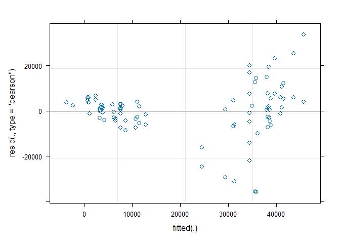

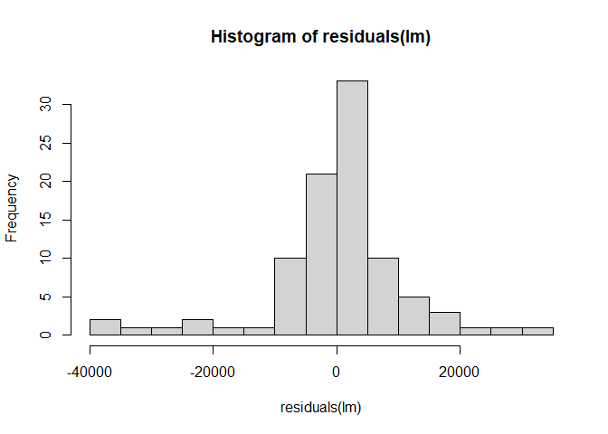

```
## [1] "the number of complete cases is 93"
```

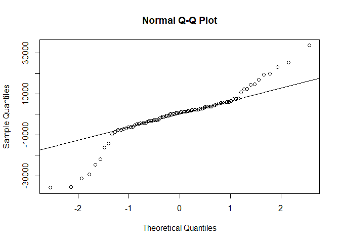

```
## Linear mixed model fit by REML. t-tests use Satterthwaite's method [
## lmerModLmerTest]
## Formula: trait ~ Treatment * Population + (1 | Population:Line)
##    Data: data
##
## REML criterion at convergence: 1956.9
##
## Scaled residuals:
##      Min       1Q   Median       3Q      Max
## -2.97677 -0.34420  0.07632  0.36589  2.79464
##
## Random effects:
##  Groups          Name        Variance  Std.Dev.
##  Population:Line (Intercept)  37372493  6113
##  Residual                    144910416 12038
## Number of obs: 93, groups:  Population:Line, 21
##
## Fixed effects:
##                        Estimate Std. Error       df t value Pr(>|t|)
## (Intercept)            20873.25    1916.28    16.51  10.893 5.95e-09 ***
## Treatment1             15482.40    1261.46    69.36  12.273  < 2e-16 ***
## Population1             -540.91    1916.28    16.51  -0.282    0.781
## Treatment1:Population1 -2006.15    1261.46    69.36  -1.590    0.116
## ---
## Signif. codes:  0 '***' 0.001 '**' 0.01 '*' 0.05 '.' 0.1 ' ' 1
##
## Correlation of Fixed Effects:
##             (Intr) Trtmn1 Ppltn1
## Treatment1  -0.006
## Population1  0.220  0.006
## Trtmnt1:Pp1  0.006  0.138 -0.006
```

```
## Computing profile confidence intervals ...
```

```
##                            2.5 %     97.5 %
## .sig01                     0.000  9834.9355
## .sigma                 10166.933 14167.4614
## (Intercept)            17125.744 24613.8151
## Treatment1             13010.983 17959.8083
## Population1            -4280.441  3207.7593
## Treatment1:Population1 -4483.566   465.2587
```

```r
fitness_anov_21 <- do_anov(fitness_lm_21)
```

```
## Type III Analysis of Variance Table with Satterthwaite's method
##                          Sum Sq    Mean Sq NumDF  DenDF  F value Pr(>F)
## Treatment            2.1829e+10 2.1829e+10     1 69.360 150.6370 <2e-16 ***
## Population           1.1546e+07 1.1546e+07     1 16.507   0.0797 0.7812
## Treatment:Population 3.6651e+08 3.6651e+08     1 69.360   2.5292 0.1163
## ---
## Signif. codes:  0 '***' 0.001 '**' 0.01 '*' 0.05 '.' 0.1 ' ' 1
```

```r
fitness_anov_21$trait <- "Total Fitness"
fitness_emmeans_21 <- get_table(fitness_lm_21)
fitness_means_21 <- as.data.frame(fitness_emmeans_21)
fitness_pairs_21 <- as.data.frame(pairs(fitness_emmeans_21))
fitness_pairs_21$trait <- "Total Fitness"

geno_fitness <- as.data.frame(get_geno_table(Dat_2021_fitness$fitness, data = Dat_2021_fitness))
geno_fitness$trait <- "TotalFitness"
```

###Outputs

1. Results table

```r
AnovaResults_2021 <- rbind(eTof_anov_21, fresh_anov_21, sat_anov_21, dry_anov_21, area_anov_21, SLA_anov_21, LDMC_anov_21, RWC_anov_21, LN_harv_anov_21, Ros_anov_21, Repro_anov_21, RR_anov_21, fruit_anov_21, AvSeedWt_anov_21, seeds_anov_21, fitness_anov_21)

write.csv(AnovaResults_2021, file = "data/AnovaResults_2021.csv", row.names = TRUE)
```

2. All the tables to read in to the figures code

```r
# change column names - order is odd as artifact from updating code
dfs <- c("eTof_means_21", "RWC_means_21", "LN_harv_means_21", "AvSeedWt_means_21", "fruit_means_21", "fitness_means_21", "fresh_means_21", 'sat_means_21', "dry_means_21", "area_means_21", "SLA_means_21", "LDMC_means_21", "Ros_means_21", "Repro_means_21", 'RR_means_21', "seeds_means_21")

for (i in dfs) {
  x=get(i)
  colnames(x) <- c("Treatment", "Population", "Mean", "SE", "Df", "LL_95", "UL_95")
  assign(i,x)
}

# create list of data frames
Means_2021 <- list(eTof_means_21, fresh_means_21, sat_means_21, dry_means_21, area_means_21, SLA_means_21, LDMC_means_21, RWC_means_21, LN_harv_means_21, Ros_means_21, Repro_means_21, RR_means_21, fruit_means_21, AvSeedWt_means_21, seeds_means_21, fitness_means_21)

# name that list
names(Means_2021) <- c("eTof_means_21", "fresh_means_21", 'sat_means_21', "dry_means_21", "area_means_21", "SLA_means_21", "LDMC_means_21", "RWC_means_21", "LN_harv_means_21", "Ros_means_21", "Repro_means_21", 'RR_means_21', "fruit_means_21", "AvSeedWt_means_21", "seeds_means_21", "fitness_means_21")

# save named list
save(Means_2021, file = "data/ModelMeans_2021.robj")
```

Save a .csv with the posthoc results

```r
PostHocResults_2021 <- rbind(eTof_pairs_21, fresh_pairs_21, sat_pairs_21, dry_pairs_21, area_pairs_21, SLA_pairs_21, LDMC_pairs_21, RWC_pairs_21, LN_harv_pairs_21, Ros_pairs_21, Repro_pairs_21, RR_pairs_21, fruit_pairs_21, AvSeedWt_pairs_21, seeds_pairs_21, fitness_pairs_21)

write.csv(PostHocResults_2021, file = "data/PostHocResults_2021.csv", row.names = TRUE)
```

genotype level information

```r
GenotypeMeans_2021 <- rbind(geno_rwc_21, geno_sla_21, geno_eTof, geno_fruits, geno_seeds, geno_fitness)
GenotypeMeans_2021$year <- "2021"
```

## Sample size information

Identify know how many lines and how many replicates per line for this experiment. The number of observations that were not NA comes from earlier in the “summarize” section.

```r
# sample size of 2021 total
Dat_2021_TwoTrt %>% count(Treatment)
```

```
##   Treatment  n
## 1   Current 50
## 2    Future 50
```

```r
# 50 plants per treatments
Dat_2021_TwoTrt %>% count(Treatment, Population)
```

```
##   Treatment Population  n
## 1   Current       BELM 20
## 2   Current       RODA 30
## 3    Future       BELM 20
## 4    Future       RODA 30
```

```r
# in each treatment, 20 are IT, 30 are SW

# there are 21 unique lines. 8 IT, 13 SW.
n_2021 <- Dat_2021_TwoTrt %>%
  group_by(Treatment) %>%
  group_by(Population, .add = TRUE) %>%
  group_by(Line, .add = TRUE) %>%
  count

# only line with 1 rep is Belm 1. Then everything has 2 but RIL parents. B12 has 7, R47 has 6.
n_2021 %>%
  group_by(Treatment) %>%
  group_by(Population, .add = TRUE) %>%
  summarize(min = min(n), mean = mean(n), median = median(n), max = max(n))
```

```
## # A tibble: 4 × 6
## # Groups:   Treatment [2]
##   Treatment Population   min  mean median   max
##   <fct>     <fct>      <int> <dbl>  <dbl> <int>
## 1 Current   BELM           1  2.5       2     7
## 2 Current   RODA           2  2.31      2     6
## 3 Future    BELM           1  2.5       2     7
## 4 Future    RODA           2  2.31      2     6
```

```r
# want to know sample sizes for fitness and such
Dat_2021_fitness %>% count(Treatment, Population)
```

```
##   Treatment Population  n
## 1   Current       BELM 20
## 2   Current       RODA 30
## 3    Future       BELM 20
## 4    Future       RODA 30
```

```r
Dat_2021_RosSeed %>% count(Treatment, Population)
```

```
##   Treatment Population  n
## 1   Current       BELM 16
## 2   Current       RODA 26
## 3    Future       BELM 16
## 4    Future       RODA 26
```

```r
Dat_2021_most %>% count(Treatment, Population)
```

```
##   Treatment Population  n
## 1   Current       BELM 16
## 2   Current       RODA 28
## 3    Future       BELM 16
## 4    Future       RODA 28
```

```r
Dat_2021_la %>% count(Treatment, Population)
```

```
##   Treatment Population  n
## 1   Current       BELM 15
## 2   Current       RODA 28
## 3    Future       BELM 15
## 4    Future       RODA 28
```

# 2022

## Read in data

```r
Dat_2022 <- read.csv("data/CleanData_2022.csv", header= TRUE)

# make factors
Dat_2022$Treatment <- as.factor(Dat_2022$Treatment)
Dat_2022$Population <- as.factor(Dat_2022$Population)
Dat_2022$PotID <- as.factor(Dat_2022$PotID)
Dat_2022$Flat <- as.factor(Dat_2022$Flat)
Dat_2022$Chamber <- as.factor(Dat_2022$Chamber)
Dat_2022$Transplanted <- as.factor(Dat_2022$Transplanted)
Dat_2022$Geno_ID <- as.factor(paste0(Dat_2022$Population, Dat_2022$Line))
```

## Summarize!

```r
# by population only
ByPop_22 <- Dat_2022 %>%
  dplyr::group_by(Population) %>%
  summarize(across(.col = c(DaysToEmergence:l10_Stomata_density), .fns = list(mean = ~mean(.x, na.rm = TRUE, .group = "keep"), ci_95 = ~conf_int(.x), n = ~sum(!is.na(.x)))))

# transpose for easier viewing
ByPop_22 <- data.frame(t(ByPop_22))

# by treatment
ByTrt_22 <- Dat_2022 %>%
  dplyr::group_by(Treatment) %>%
  summarize(across(.col = c(DaysToEmergence:l10_Stomata_density), .fns = list(mean = ~mean(.x, na.rm = TRUE, .group = "keep"), ci_95 = ~conf_int(.x), n = ~sum(!is.na(.x)))))
ByTrt_22 <- data.frame(t(ByTrt_22))

# population means within each treatment
ByTrt_Pop_22 <- Dat_2022 %>%
  dplyr::group_by(Population) %>%
  dplyr::group_by(Treatment, .add = TRUE) %>%
  summarize(across(.col = c(DaysToEmergence:l10_Stomata_density), .fns = list(mean = ~mean(.x, na.rm = TRUE, .group = "keep"), ci_95 = ~conf_int(.x), n = ~sum(!is.na(.x)))))
# get the sample sizes
SampleSizes_2022 <- dplyr::select(ByTrt_Pop_22, "Treatment", "Population", ends_with("_n"))
save(SampleSizes_2022, file = "data/SampleSizes_2022.robj")

# for some ease of viewing
ByTrt_Pop_22 <- data.frame(t(ByTrt_Pop_22))
colnames(ByTrt_Pop_22) <- c("Belm_C", "Belm_F", "Roda_C", "Roda_F")

# save this to keep means
write.csv(ByTrt_Pop_22,"data/PopMeansByTreatment_2022.csv", row.names = TRUE )
```

subset to the trait that are in the manuscript

```r
Dat_2022c <- Dat_2022[,c("PotID", "Treatment", "Population", "Line", "Geno_ID", "Replicate", "Chamber", "Flat", "Transplanted", "l10_SL_FreshWt", "l10_SL_HydWt", "SL_DryWt", "SL_Area", "l10_SLA", "l10_LDMC", "RWC", "l10_LeafNumber_Total", "l10_AG_DryBiomass", "BG_DryBiomass", "l10_Root_to_Shoot", "TotalBiomass", "l10_Stomata_density", "SLA", "LDMC") ]

# remove B4 Fut because there is no matching B4 current
Dat_2022c <- Dat_2022c[!(Dat_2022c$PotID %in% c("B4-2-F")), ]

# to check for outliers, remove Roda-11 which is a high outlier in the biomass traits
Dat_2022c_outliers <- Dat_2022c[!(Dat_2022c$Geno_ID %in% c("R11")), ]
```

## Anovas

Now, we can make some models. Initially there were three models for this analysis.

For traits collected before bolting: trait ~ Treatment * Population + (1|Population:Line) + (1|Treatment:Chamber) + (1|Transplanted)

For traits collected when a single leaf was harvesting: trait ~ Treatment * Population + (1|BoltingToHarvest) + (1|Population:Line) + (1|Treatment:Chamber) + (1|Transplanted)

For root harvesting traits: trait ~ Treatment * Population + (1|BoltingToRootWashing) + (1|Population:Line) + (1|Treatment:Chamber) + (1|Transplanted)

Chamber nested within treatment was changed to a fixed effect because models struggle to fit a variance with few groups. The Bolting to harvest and bolting to root washing variables were also removed because they are continuous but being treated like categorical as a random effect. These two variables did explain some variation and removing sometimes increased and sometimes decreased both effect sizes and p values.

There is a population bias where only Italian lines were transplanted. 17 plants from 6 genotypes were transplanted. They became 10 current plants and 7 future plants. **However, when included, the transplanting effect sometimes explains 0 variance** Because this is such a small number (17 plants of 127 plants), the transplanting effect was removed from the model. All models were run with and without transplanting as a fixed effect, but only small changes were seen in 3 traits (see data/ModelResults_InitalModels.xlsx for notes.)

Final model: trait ~ Treatment * Population + Treatment:Chamber + (1|Population:Line)

```r
# set contrasts for models to ensure we are doing the correct type of ANOVA (type-III)
contrasts(Dat_2022c$Population) <- contr.sum
contrasts(Dat_2022c$Treatment) <- contr.sum

# make a modelling function to streamline analyses. This function follows the same pattern as from 2021 analysis

do_lmer2 <- function(trait, data = Dat_2022c){
  lm<- lmer(trait ~ Treatment * Population + Treatment/Chamber + (1|Population:Line), data = data, contrasts = list(Treatment=contr.sum, Population = contr.sum))
  print(plot(lm))
  hist(residuals(lm), breaks = 15)
  #plotting sanity check
  print(paste0("the number of complete cases is ", sum(complete.cases(trait))))
  # make qq plot
  qqnorm(resid(lm))
  qqline(resid(lm))
  print(summary(lm))
  print(confint(lm))
  return(lm)
}
# do the anova
do_anov2 <- function(model){
  anov <- anova(model)
  print(anov)
  df <- as.data.frame(anov)
  df$exp <- "2022"
  return(df)
}

# get table functions are the same as from 2021

# geno get table functions need to be updated
get_geno_table22 <- function (trait, data = Dat_2022c){
  tab2 <- emmeans(lm(trait ~ Treatment * Geno_ID, data = data, contrasts = list(Treatment=contr.sum, Geno_ID = contr.sum)), c("Treatment", "Geno_ID"), type = "reponse")
  return(tab2)
}

get_geno_table_bt22 <- function(trait, data = Dat_2022c){
  mod <- lm(trait ~ Treatment * Geno_ID, data = data, contrasts = list(Treatment=contr.sum, Geno_ID = contr.sum))
  tab2 <- emmeans(update(ref_grid(mod), tran = "log10"), c("Treatment", "Geno_ID"), type = "response") #
  return(tab2)
}
```

Run the models

### Single Leaf Traits: bolting

Fresh weight

```r
# single leaf fresh weight
fresh_lm_22 <- do_lmer2(Dat_2022c$l10_SL_FreshWt)
```

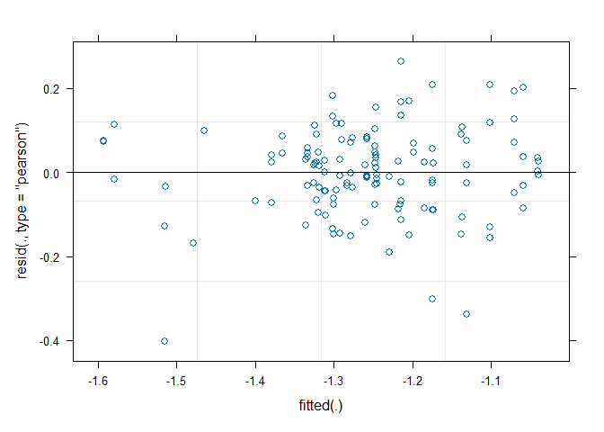

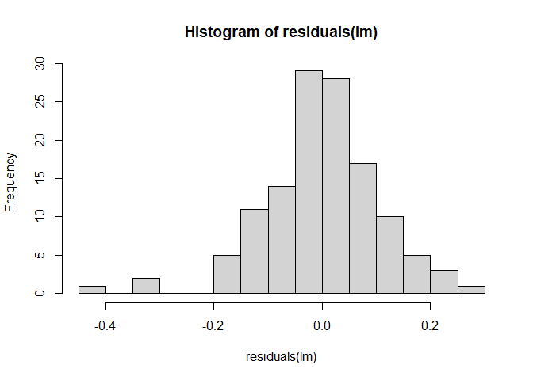

```
## [1] "the number of complete cases is 126"
```

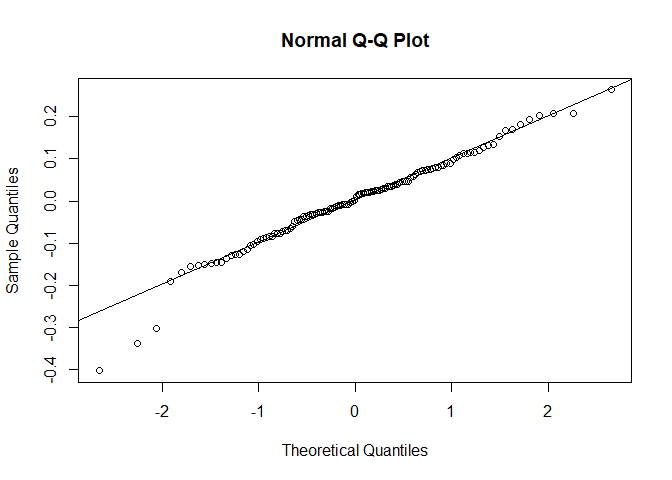

```
## Linear mixed model fit by REML. t-tests use Satterthwaite's method [
## lmerModLmerTest]
## Formula:
## trait ~ Treatment * Population + Treatment/Chamber + (1 | Population:Line)
##    Data: data
##
## REML criterion at convergence: -130.3
##
## Scaled residuals:
##     Min      1Q  Median      3Q     Max
## -3.5428 -0.5694  0.0609  0.6186  2.3219
##
## Random effects:
##  Groups          Name        Variance Std.Dev.
##  Population:Line (Intercept) 0.00818  0.09045
##  Residual                    0.01290  0.11358
## Number of obs: 126, groups:  Population:Line, 15
##
## Fixed effects:
##                             Estimate Std. Error         df t value Pr(>|t|)
## (Intercept)               -1.267e+00  2.566e-02  1.235e+01 -49.383 1.44e-15 ***
## Treatment1                 5.584e-02  1.015e-02  1.068e+02   5.503 2.59e-07 ***
## Population1               -8.016e-02  2.566e-02  1.235e+01  -3.124  0.00852 **
## Treatment1:Population1    -2.020e-02  1.015e-02  1.068e+02  -1.990  0.04918 *
## TreatmentCurrent:Chamber1  2.829e-04  1.426e-02  1.070e+02   0.020  0.98420
## TreatmentFuture:Chamber1  -6.928e-03  1.447e-02  1.067e+02  -0.479  0.63312
## ---
## Signif. codes:  0 '***' 0.001 '**' 0.01 '*' 0.05 '.' 0.1 ' ' 1
##
## Correlation of Fixed Effects:
##             (Intr) Trtmn1 Ppltn1 Tr1:P1 TrC:C1
## Treatment1  -0.001
## Population1  0.068  0.006
## Trtmnt1:Pp1  0.006  0.004 -0.001
## TrtmntCr:C1 -0.005  0.000 -0.005  0.000
## TrtmntFt:C1 -0.001  0.001  0.009 -0.024  0.001
```

```
## Computing profile confidence intervals ...
```

```
##                                 2.5 %        97.5 %
## .sig01                     0.05240058  0.1333018134
## .sigma                     0.09831362  0.1280782583
## (Intercept)               -1.31758630 -1.2175464298
## Treatment1                 0.03626581  0.0757056094
## Population1               -0.13064846 -0.0305980089
## Treatment1:Population1    -0.03979323 -0.0003516074
## TreatmentCurrent:Chamber1 -0.02736820  0.0279901987
## TreatmentFuture:Chamber1  -0.03505219  0.0211517149
```

```r
fresh_anov_22 <- do_anov2(fresh_lm_22)
```

```
## Type III Analysis of Variance Table with Satterthwaite's method
##                        Sum Sq  Mean Sq NumDF   DenDF F value    Pr(>F)
## Treatment            0.221526 0.221526     1 106.655 17.1717 6.863e-05 ***
## Population           0.125903 0.125903     1  12.353  9.7594  0.008517 **
## Treatment:Population 0.051070 0.051070     1 106.787  3.9588  0.049185 *
## Treatment:Chamber    0.002962 0.001481     2 106.825  0.1148  0.891657
## ---
## Signif. codes:  0 '***' 0.001 '**' 0.01 '*' 0.05 '.' 0.1 ' ' 1
```

```r
fresh_anov_22$trait <- "l10_FreshWt"
fresh_emmeans_22 <- get_table_bt(fresh_lm_22)
```

```
## NOTE: A nesting structure was detected in the fitted model:
##     Chamber %in% Treatment
```

```r
fresh_means_22 <- as.data.frame(fresh_emmeans_22)
fresh_pairs_22 <- as.data.frame(pairs(fresh_emmeans_22))
fresh_pairs_22$trait <- "l10_FreshWt"
```

Saturated/Hydrated weight

```r
# single leaf hydrated (also called saturated) weight
hyd_lm_22 <- do_lmer2(Dat_2022c$l10_SL_HydWt)
```

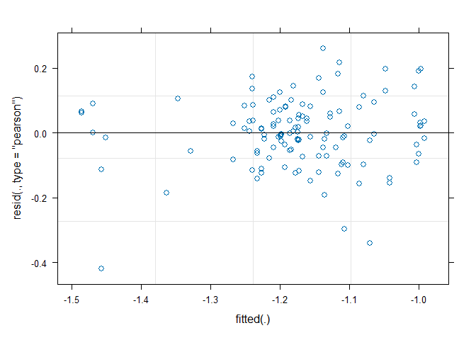

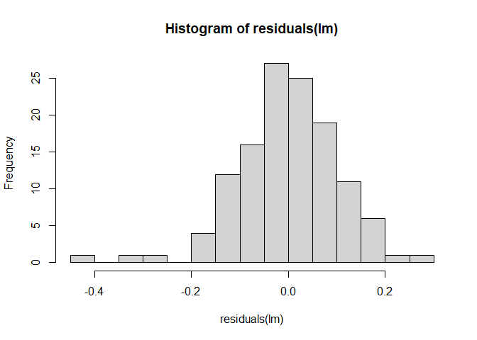

```
## [1] "the number of complete cases is 125"
```

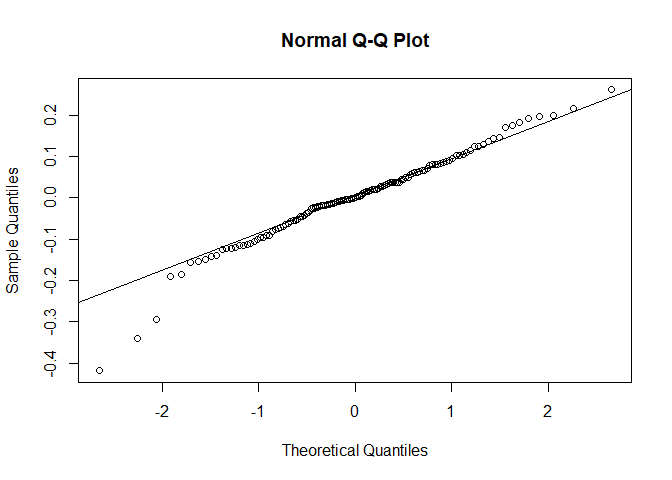

```
## Linear mixed model fit by REML. t-tests use Satterthwaite's method [
## lmerModLmerTest]
## Formula:
## trait ~ Treatment * Population + Treatment/Chamber + (1 | Population:Line)
##    Data: data
##
## REML criterion at convergence: -128.5
##
## Scaled residuals:
##     Min      1Q  Median      3Q     Max
## -3.6821 -0.4980  0.0054  0.5718  2.2974
##
## Random effects:
##  Groups          Name        Variance Std.Dev.
##  Population:Line (Intercept) 0.008383 0.09156
##  Residual                    0.012931 0.11371
## Number of obs: 125, groups:  Population:Line, 15
##
## Fixed effects:
##                             Estimate Std. Error         df t value Pr(>|t|)
## (Intercept)                -1.184215   0.025947  12.398846 -45.639 3.44e-15 ***
## Treatment1                  0.036964   0.010206 105.857841   3.622 0.000451 ***
## Population1                -0.070927   0.025949  12.403152  -2.733 0.017696 *
## Treatment1:Population1     -0.025367   0.010213 105.863195  -2.484 0.014563 *
## TreatmentCurrent:Chamber1   0.003270   0.014273 106.013154   0.229 0.819249
## TreatmentFuture:Chamber1   -0.008237   0.014631 105.792889  -0.563 0.574617
## ---
## Signif. codes:  0 '***' 0.001 '**' 0.01 '*' 0.05 '.' 0.1 ' ' 1
##
## Correlation of Fixed Effects:
##             (Intr) Trtmn1 Ppltn1 Tr1:P1 TrC:C1
## Treatment1  -0.004
## Population1  0.066  0.010
## Trtmnt1:Pp1  0.010 -0.006 -0.005
## TrtmntCr:C1 -0.005  0.000 -0.005  0.000
## TrtmntFt:C1 -0.006  0.015  0.014 -0.038  0.001
```

```
## Computing profile confidence intervals ...
```

```
##                                 2.5 %      97.5 %
## .sig01                     0.05326732  0.13480768
## .sigma                     0.09835816  0.12828129
## (Intercept)               -1.23521437 -1.13406237
## Treatment1                 0.01729170  0.05696481
## Population1               -0.12199122 -0.02081372
## Treatment1:Population1    -0.04509826 -0.00542650
## TreatmentCurrent:Chamber1 -0.02440600  0.03101210
## TreatmentFuture:Chamber1  -0.03663003  0.02018222
```

```r
hyd_anov_22 <- do_anov2(hyd_lm_22)
```

```
## Type III Analysis of Variance Table with Satterthwaite's method
##                        Sum Sq  Mean Sq NumDF   DenDF F value   Pr(>F)
## Treatment            0.114391 0.114391     1 105.702  8.8464 0.003639 **
## Population           0.096603 0.096603     1  12.403  7.4708 0.017696 *
## Treatment:Population 0.079781 0.079781     1 105.863  6.1698 0.014563 *
## Treatment:Chamber    0.004782 0.002391     2 105.903  0.1849 0.831450
## ---
## Signif. codes:  0 '***' 0.001 '**' 0.01 '*' 0.05 '.' 0.1 ' ' 1
```

```r
hyd_anov_22$trait <- "l10_SatWt"
hyd_emmeans_22 <- get_table_bt(hyd_lm_22)
```

```
## NOTE: A nesting structure was detected in the fitted model:
##     Chamber %in% Treatment
```

```r
hyd_means_22 <- as.data.frame(hyd_emmeans_22)
hyd_pairs_22 <- as.data.frame(pairs(hyd_emmeans_22))
hyd_pairs_22$trait <- "l10_SatWt"

## also has SQR transformation. Pop becomes more significant but no other significance changes
#hyd_lm_22SQR <- do_lmer2(Dat_2022c$SQR_SL_HydWt)
#hyd_anov_22SQR <- do_anov2(hyd_lm_22SQR)
#hyd_anov_22SQR$trait <- "l10_SatWt"
```

Dried weight

```r
# single leaf dry weight
dry_lm_22 <- do_lmer2(Dat_2022c$SL_DryWt)
```

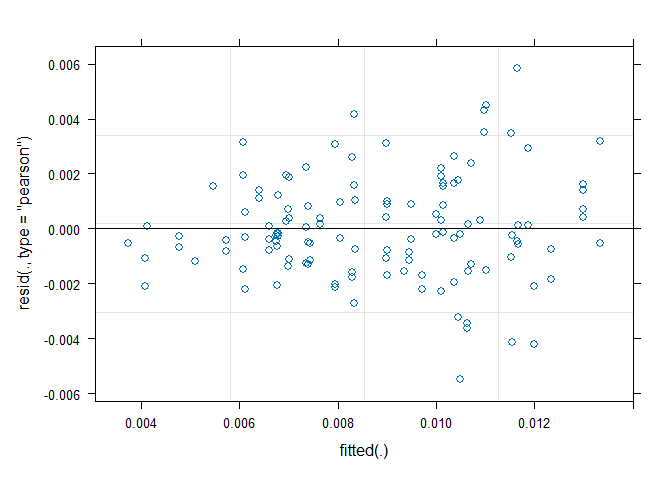

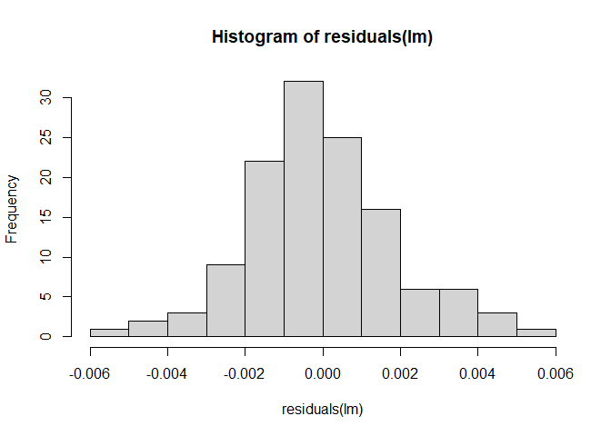

```
## [1] "the number of complete cases is 126"
```

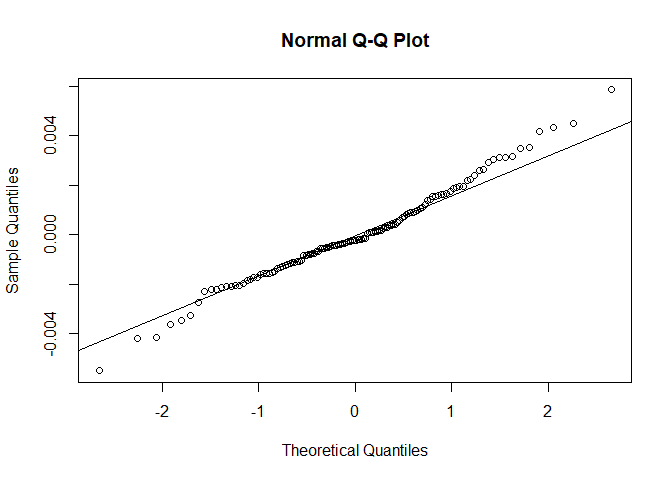

```
## Linear mixed model fit by REML. t-tests use Satterthwaite's method [
## lmerModLmerTest]
## Formula:
## trait ~ Treatment * Population + Treatment/Chamber + (1 | Population:Line)
##    Data: data
##
## REML criterion at convergence: -1101.8
##
## Scaled residuals:
##     Min      1Q  Median      3Q     Max
## -2.7439 -0.5720 -0.1213  0.5140  2.9204
##
## Random effects:
##  Groups          Name        Variance  Std.Dev.
##  Population:Line (Intercept) 2.084e-06 0.001443
##  Residual                    4.003e-06 0.002001
## Number of obs: 126, groups:  Population:Line, 15
##
## Fixed effects:
##                             Estimate Std. Error         df t value Pr(>|t|)
## (Intercept)                8.620e-03  4.168e-04  1.273e+01  20.684 3.54e-11 ***
## Treatment1                -1.037e-05  1.787e-04  1.073e+02  -0.058 0.953844
## Population1               -2.108e-03  4.168e-04  1.273e+01  -5.057 0.000234 ***
## Treatment1:Population1    -2.574e-04  1.788e-04  1.073e+02  -1.440 0.152788
## TreatmentCurrent:Chamber1 -1.726e-04  2.511e-04  1.075e+02  -0.688 0.493231
## TreatmentFuture:Chamber1   3.256e-04  2.549e-04  1.072e+02   1.277 0.204295
## ---
## Signif. codes:  0 '***' 0.001 '**' 0.01 '*' 0.05 '.' 0.1 ' ' 1
##
## Correlation of Fixed Effects:
##             (Intr) Trtmn1 Ppltn1 Tr1:P1 TrC:C1
## Treatment1  -0.001
## Population1  0.067  0.006
## Trtmnt1:Pp1  0.006  0.004 -0.001
## TrtmntCr:C1 -0.005  0.000 -0.005  0.000
## TrtmntFt:C1 -0.001  0.001  0.010 -0.024  0.001
```

```
## Computing profile confidence intervals ...
```

```
##                                   2.5 %        97.5 %
## .sig01                     0.0008218550  2.140457e-03
## .sigma                     0.0017319610  2.254773e-03
## (Intercept)                0.0078022876  9.426432e-03
## Treatment1                -0.0003555995  3.386140e-04
## Population1               -0.0029261717 -1.301827e-03
## Treatment1:Population1    -0.0006031773  9.109266e-05
## TreatmentCurrent:Chamber1 -0.0006594980  3.152035e-04
## TreatmentFuture:Chamber1  -0.0001695606  8.201417e-04
```

```r
dry_anov_22 <- do_anov2(dry_lm_22)
```

```
## Type III Analysis of Variance Table with Satterthwaite's method
##                          Sum Sq    Mean Sq NumDF   DenDF F value    Pr(>F)
## Treatment            4.2210e-06 4.2210e-06     1 107.128  1.0544 0.3068113
## Population           1.0237e-04 1.0237e-04     1  12.734 25.5708 0.0002343 ***
## Treatment:Population 8.3010e-06 8.3010e-06     1 107.266  2.0735 0.1527883
## Treatment:Chamber    8.4320e-06 4.2160e-06     2 107.311  1.0531 0.3524321
## ---
## Signif. codes:  0 '***' 0.001 '**' 0.01 '*' 0.05 '.' 0.1 ' ' 1
```

```r
dry_anov_22$trait <- "DriedWt"
dry_emmeans_22 <- get_table(dry_lm_22)
```

```
## NOTE: A nesting structure was detected in the fitted model:
##     Chamber %in% Treatment
```

```r
dry_means_22 <- as.data.frame(dry_emmeans_22)
dry_pairs_22 <- as.data.frame(pairs(dry_emmeans_22))
dry_pairs_22$trait <- "DriedWt"

# what about SQR transformation - no meaningful change
#anov_lmer2(Dat_2022c$SQR_SL_DryWt)

# and what about l10 transformation - no meaningful change
#anov_lmer2(log10(Dat_2022c$SL_DryWt))
```

leaf area

```r
# single leaf area
area_lm_22 <- do_lmer2(Dat_2022c$SL_Area)
```

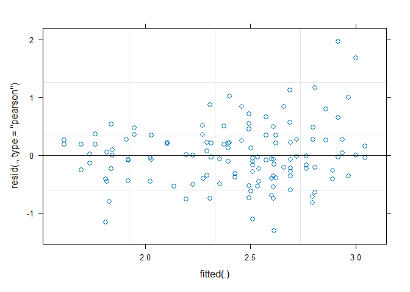

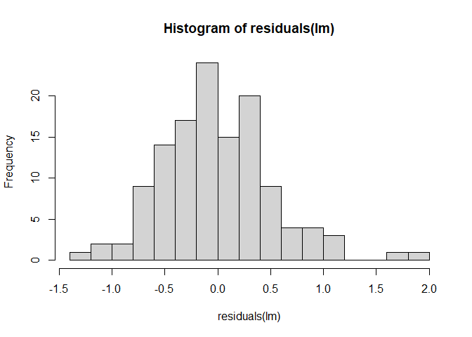

```
## [1] "the number of complete cases is 126"
```

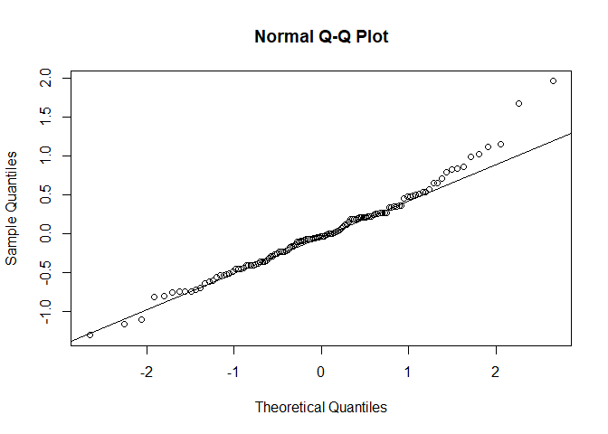

```
## Linear mixed model fit by REML. t-tests use Satterthwaite's method [
## lmerModLmerTest]
## Formula:
## trait ~ Treatment * Population + Treatment/Chamber + (1 | Population:Line)
##    Data: data
##
## REML criterion at convergence: 246.7
##
## Scaled residuals:
##     Min      1Q  Median      3Q     Max
## -2.3425 -0.6530 -0.0618  0.4761  3.5142
##
## Random effects:
##  Groups          Name        Variance Std.Dev.
##  Population:Line (Intercept) 0.1169   0.3419
##  Residual                    0.3124   0.5589
## Number of obs: 126, groups:  Population:Line, 15
##
## Fixed effects:
##                             Estimate Std. Error         df t value Pr(>|t|)
## (Intercept)                 2.377930   0.102324  11.617488  23.239 4.22e-11 ***
## Treatment1                  0.222206   0.049916 106.236915   4.452 2.11e-05 ***
## Population1                -0.001582   0.102331  11.620540  -0.015   0.9879
## Treatment1:Population1     -0.116407   0.049930 106.241279  -2.331   0.0216 *
## TreatmentCurrent:Chamber1   0.053933   0.070110 106.494639   0.769   0.4434
## TreatmentFuture:Chamber1   -0.040675   0.071197 106.120011  -0.571   0.5690
## ---
## Signif. codes:  0 '***' 0.001 '**' 0.01 '*' 0.05 '.' 0.1 ' ' 1
##
## Correlation of Fixed Effects:
##             (Intr) Trtmn1 Ppltn1 Tr1:P1 TrC:C1
## Treatment1  -0.002
## Population1  0.065  0.006
## Trtmnt1:Pp1  0.006  0.003 -0.002
## TrtmntCr:C1 -0.005  0.000 -0.005  0.000
## TrtmntFt:C1 -0.001  0.001  0.011 -0.024  0.001
```

```
## Computing profile confidence intervals ...
```

```
##                                2.5 %      97.5 %
## .sig01                     0.1669399  0.52303941
## .sigma                     0.4837860  0.63093165
## (Intercept)                2.1752615  2.57479488
## Treatment1                 0.1260205  0.32019615
## Population1               -0.2044754  0.19517500
## Treatment1:Population1    -0.2127714 -0.01863419
## TreatmentCurrent:Chamber1 -0.0823265  0.19004893
## TreatmentFuture:Chamber1  -0.1790099  0.09762231
```

```r
area_anov_22 <- do_anov2(area_lm_22)
```

```
## Type III Analysis of Variance Table with Satterthwaite's method
##                      Sum Sq Mean Sq NumDF   DenDF F value    Pr(>F)
## Treatment            4.5555  4.5555     1 106.079 14.5826 0.0002262 ***
## Population           0.0001  0.0001     1  11.621  0.0002 0.9879259
## Treatment:Population 1.6980  1.6980     1 106.241  5.4354 0.0216191 *
## Treatment:Chamber    0.2872  0.1436     2 106.307  0.4596 0.6327833
## ---
## Signif. codes:  0 '***' 0.001 '**' 0.01 '*' 0.05 '.' 0.1 ' ' 1
```

```r
area_anov_22$trait <- "Area"
area_emmeans_22 <- get_table(area_lm_22)
```

```
## NOTE: A nesting structure was detected in the fitted model:
##     Chamber %in% Treatment
```

```r
area_means_22 <- as.data.frame(area_emmeans_22)
area_pairs_22 <- as.data.frame(pairs(area_emmeans_22))
area_pairs_22$trait <- "Area"
## also has SQR - no significance changes
#area_lm_22SQR <- do_lmer2(Dat_2022c$SQR_SL_Area)
#area_anov_22SQR <- do_anov2(area_lm_22SQR)
#area_anov_22SQR$trait <- "SQR_Area"
```

leaf perimeter

```r
# single leaf perimeter
per_lm_22 <- do_lmer2(Dat_2022c$SL_Perim)
per_anov_22 <- do_anov2(per_lm_22)
per_anov_22$trait <- "Perimeter"
per_emmeans_22 <- get_table(per_lm_22)
per_means_22 <- as.data.frame(per_emmeans_22)
per_pairs_22 <- as.data.frame(pairs(per_emmeans_22))
per_pairs_22$trait <- "Perimeter"
```

[output not shown]

specific leaf area

```r
# SLA
sla_lm_22 <- do_lmer2(Dat_2022c$l10_SLA)
```

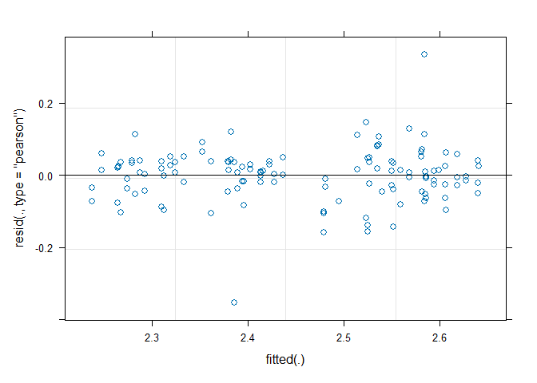

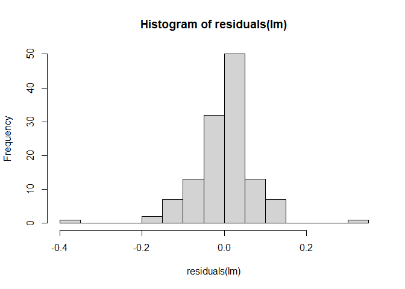

```
## [1] "the number of complete cases is 126"
```

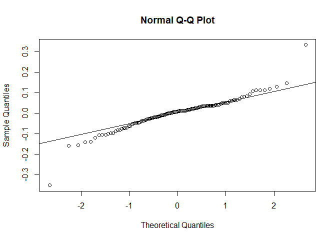

```
## Linear mixed model fit by REML. t-tests use Satterthwaite's method [
## lmerModLmerTest]
## Formula:
## trait ~ Treatment * Population + Treatment/Chamber + (1 | Population:Line)
##    Data: data
##
## REML criterion at convergence: -235.6
##
## Scaled residuals:
##     Min      1Q  Median      3Q     Max
## -4.5530 -0.4379  0.1025  0.4758  4.2996
##
## Random effects:
##  Groups          Name        Variance  Std.Dev.
##  Population:Line (Intercept) 0.0008014 0.02831
##  Residual                    0.0060312 0.07766
## Number of obs: 126, groups:  Population:Line, 15
##
## Fixed effects:
##                             Estimate Std. Error         df t value Pr(>|t|)
## (Intercept)                 2.453188   0.010168  13.276368 241.264  < 2e-16 ***
## Treatment1                  0.043488   0.006930 108.599128   6.275 7.30e-09 ***
## Population1                 0.110813   0.010169  13.283008  10.897 5.35e-08 ***
## Treatment1:Population1     -0.011027   0.006932 108.605124  -1.591   0.1146
## TreatmentCurrent:Chamber1   0.016844   0.009729 108.911026   1.731   0.0862 .
## TreatmentFuture:Chamber1   -0.022590   0.009886 108.571973  -2.285   0.0242 *
## ---
## Signif. codes:  0 '***' 0.001 '**' 0.01 '*' 0.05 '.' 0.1 ' ' 1
##
## Correlation of Fixed Effects:
##             (Intr) Trtmn1 Ppltn1 Tr1:P1 TrC:C1
## Treatment1  -0.006
## Population1  0.052  0.005
## Trtmnt1:Pp1  0.005  0.002 -0.007
## TrtmntCr:C1 -0.004  0.000 -0.004  0.000
## TrtmntFt:C1 -0.001  0.001  0.016 -0.024  0.001
```

```
## Computing profile confidence intervals ...
```

```
##                                  2.5 %       97.5 %
## .sig01                     0.000000000  0.047630621
## .sigma                     0.067242501  0.087398181
## (Intercept)                2.433383705  2.472959296
## Treatment1                 0.030036971  0.056925527
## Population1                0.091005932  0.130585816
## Treatment1:Population1    -0.024482447  0.002413538
## TreatmentCurrent:Chamber1 -0.002157921  0.035610995
## TreatmentFuture:Chamber1  -0.041701713 -0.003335622
```

```r
sla_anov_22 <- do_anov2(sla_lm_22)
```

```
## Type III Analysis of Variance Table with Satterthwaite's method
##                       Sum Sq Mean Sq NumDF   DenDF  F value    Pr(>F)
## Treatment            0.25086 0.25086     1 108.472  41.5926 3.214e-09 ***
## Population           0.71614 0.71614     1  13.283 118.7392 5.347e-08 ***
## Treatment:Population 0.01526 0.01526     1 108.605   2.5308   0.11455
## Treatment:Chamber    0.04961 0.02481     2 108.741   4.1129   0.01897 *
## ---
## Signif. codes:  0 '***' 0.001 '**' 0.01 '*' 0.05 '.' 0.1 ' ' 1
```

```r
sla_anov_22$trait <- "l10_SLA"
sla_emmeans_22 <- get_table_bt(sla_lm_22)
```

```
## NOTE: A nesting structure was detected in the fitted model:
##     Chamber %in% Treatment
```

```r
sla_means_22 <- as.data.frame(sla_emmeans_22)
sla_pairs_22 <- as.data.frame(pairs(sla_emmeans_22))
sla_pairs_22$trait <- "l10_SLA"

geno_sla_22 <- as.data.frame(get_geno_table_bt22(Dat_2022c$l10_SLA))
geno_sla_22$trait <- "l10_SLA"
```

leaf dry matter content

```r
# leaf dry matter content
ldmc_lm_22 <- do_lmer2(Dat_2022c$l10_LDMC)
```

```
## boundary (singular) fit: see help('isSingular')
```

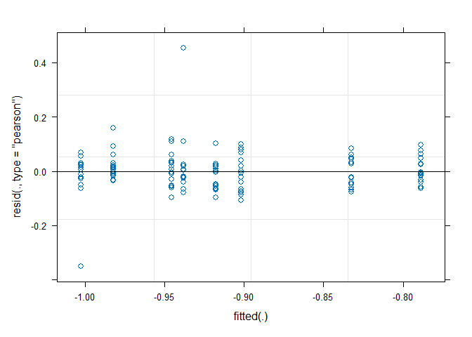

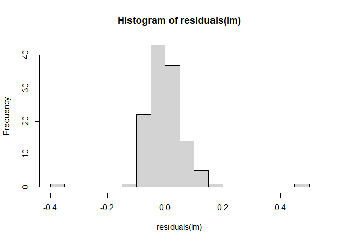

```
## [1] "the number of complete cases is 125"
```

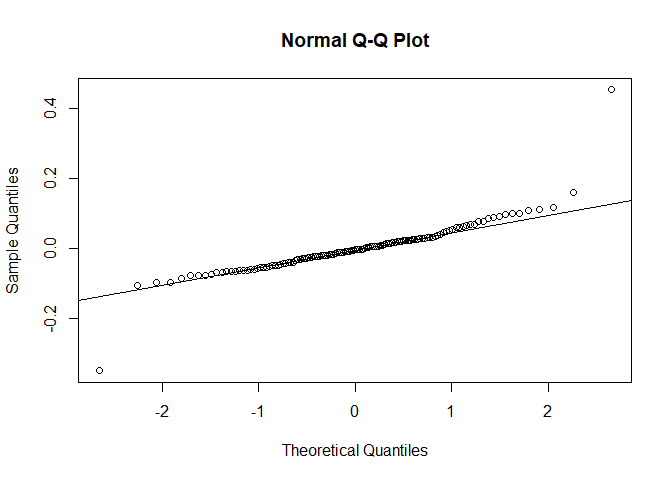

```
## Linear mixed model fit by REML. t-tests use Satterthwaite's method [
## lmerModLmerTest]
## Formula:
## trait ~ Treatment * Population + Treatment/Chamber + (1 | Population:Line)
##    Data: data
##
## REML criterion at convergence: -253.2
##
## Scaled residuals:
##     Min      1Q  Median      3Q     Max
## -4.7101 -0.5335 -0.0449  0.3689  6.1103
##
## Random effects:
##  Groups          Name        Variance Std.Dev.
##  Population:Line (Intercept) 0.000000 0.00000
##  Residual                    0.005529 0.07436
## Number of obs: 125, groups:  Population:Line, 15
##
## Fixed effects:
##                             Estimate Std. Error         df  t value Pr(>|t|)
## (Intercept)                -0.913736   0.006654 119.000000 -137.328  < 2e-16
## Treatment1                 -0.046505   0.006654 119.000000   -6.989 1.72e-10
## Population1                -0.044450   0.006657 119.000000   -6.677 8.21e-10
## Treatment1:Population1      0.012118   0.006657 119.000000    1.820   0.0712
## TreatmentCurrent:Chamber1  -0.010191   0.009295 119.000000   -1.096   0.2751
## TreatmentFuture:Chamber1    0.021907   0.009534 119.000000    2.298   0.0233
##
## (Intercept)               ***
## Treatment1                ***
## Population1               ***
## Treatment1:Population1    .
## TreatmentCurrent:Chamber1
## TreatmentFuture:Chamber1  *
## ---
## Signif. codes:  0 '***' 0.001 '**' 0.01 '*' 0.05 '.' 0.1 ' ' 1
##
## Correlation of Fixed Effects:
##             (Intr) Trtmn1 Ppltn1 Tr1:P1 TrC:C1
## Treatment1  -0.024
## Population1 -0.009  0.009
## Trtmnt1:Pp1  0.009 -0.009 -0.025
## TrtmntCr:C1  0.000  0.000  0.000  0.000
## TrtmntFt:C1 -0.012  0.012  0.035 -0.035  0.000
## optimizer (nloptwrap) convergence code: 0 (OK)
## boundary (singular) fit: see help('isSingular')
```

```
## Computing profile confidence intervals ...
```

```
##                                   2.5 %       97.5 %
## .sig01                     0.0000000000  0.023499145
## .sigma                     0.0644091753  0.082565927
## (Intercept)               -0.9265587959 -0.900913792
## Treatment1                -0.0593278615 -0.033682858
## Population1               -0.0572799095 -0.031620757
## Treatment1:Population1    -0.0007112704  0.024947883
## TreatmentCurrent:Chamber1 -0.0281032046  0.007721268
## TreatmentFuture:Chamber1   0.0035343345  0.040279072
```

```r
ldmc_anov_22 <- do_anov2(ldmc_lm_22)
```

```
## Type III Analysis of Variance Table with Satterthwaite's method
##                        Sum Sq  Mean Sq NumDF DenDF F value    Pr(>F)
## Treatment            0.246392 0.246392     1   119 44.5626 8.267e-10 ***
## Population           0.246493 0.246493     1   119 44.5809 8.211e-10 ***
## Treatment:Population 0.018321 0.018321     1   119  3.3135   0.07123 .
## Treatment:Chamber    0.035841 0.017921     2   119  3.2411   0.04260 *
## ---
## Signif. codes:  0 '***' 0.001 '**' 0.01 '*' 0.05 '.' 0.1 ' ' 1
```

```r
ldmc_anov_22$trait <- "l10_LDMC"
ldmc_emmeans_22 <- get_table_bt(ldmc_lm_22)
```

```
## NOTE: A nesting structure was detected in the fitted model:
##     Chamber %in% Treatment
```

```r
ldmc_means_22 <- as.data.frame(ldmc_emmeans_22)
ldmc_pairs_22 <- as.data.frame(pairs(ldmc_emmeans_22))
ldmc_pairs_22$trait <- "l10_LDMC"
```

relative water content

```r
# relative water content
rwc_lm_22 <- do_lmer2(Dat_2022c$RWC)
```

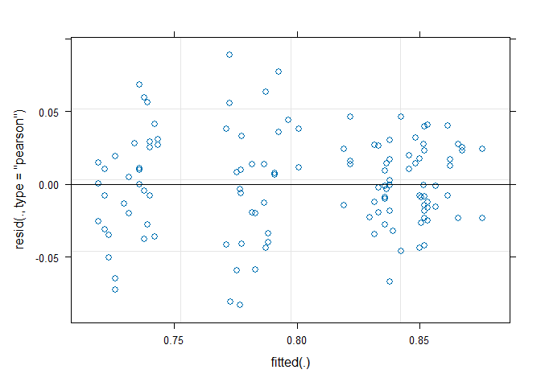

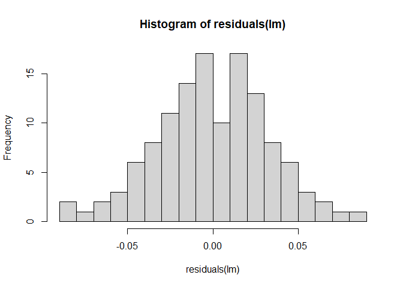

```
## [1] "the number of complete cases is 125"
```

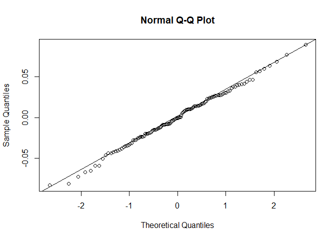

```
## Linear mixed model fit by REML. t-tests use Satterthwaite's method [
## lmerModLmerTest]
## Formula:
## trait ~ Treatment * Population + Treatment/Chamber + (1 | Population:Line)
##    Data: data
##
## REML criterion at convergence: -426.5
##
## Scaled residuals:
##      Min       1Q   Median       3Q      Max
## -2.40090 -0.58133 -0.02806  0.69442  2.56652
##
## Random effects:
##  Groups          Name        Variance  Std.Dev.
##  Population:Line (Intercept) 0.0001462 0.01209
##  Residual                    0.0011956 0.03458
## Number of obs: 125, groups:  Population:Line, 15
##
## Fixed effects:
##                             Estimate Std. Error         df t value Pr(>|t|)
## (Intercept)                 0.801776   0.004440  12.589426 180.594  < 2e-16 ***
## Treatment1                  0.043655   0.003099 107.122130  14.086  < 2e-16 ***
## Population1                -0.016416   0.004441  12.603259  -3.697  0.00282 **
## Treatment1:Population1      0.008720   0.003101 107.133783   2.812  0.00586 **
## TreatmentCurrent:Chamber1  -0.007034   0.004331 107.369225  -1.624  0.10731
## TreatmentFuture:Chamber1    0.002129   0.004443 107.212545   0.479  0.63273
## ---
## Signif. codes:  0 '***' 0.001 '**' 0.01 '*' 0.05 '.' 0.1 ' ' 1
##
## Correlation of Fixed Effects:
##             (Intr) Trtmn1 Ppltn1 Tr1:P1 TrC:C1
## Treatment1  -0.013
## Population1  0.046  0.012
## Trtmnt1:Pp1  0.012 -0.007 -0.014
## TrtmntCr:C1 -0.004  0.000 -0.004  0.000
## TrtmntFt:C1 -0.010  0.014  0.025 -0.037  0.001
```

```
## Computing profile confidence intervals ...
```

```
##                                  2.5 %       97.5 %
## .sig01                     0.000000000  0.020750073
## .sigma                     0.029917226  0.038972815
## (Intercept)                0.793181340  0.810467645
## Treatment1                 0.037634903  0.049663723
## Population1               -0.025030082 -0.007743050
## Treatment1:Population1     0.002673804  0.014712938
## TreatmentCurrent:Chamber1 -0.015480601  0.001334921
## TreatmentFuture:Chamber1  -0.006454109  0.010795416
```

```r
rwc_anov_22 <- do_anov2(rwc_lm_22)
```

```
## Type III Analysis of Variance Table with Satterthwaite's method
##                        Sum Sq  Mean Sq NumDF   DenDF F value    Pr(>F)
## Treatment            0.095877 0.095877     1 106.910 80.1915 1.182e-14 ***
## Population           0.016337 0.016337     1  12.603 13.6646  0.002823 **
## Treatment:Population 0.009454 0.009454     1 107.134  7.9072  0.005857 **
## Treatment:Chamber    0.003429 0.001715     2 107.291  1.4342  0.242841
## ---
## Signif. codes:  0 '***' 0.001 '**' 0.01 '*' 0.05 '.' 0.1 ' ' 1
```

```r
rwc_anov_22$trait <- "RWC"
rwc_emmeans_22 <- get_table(rwc_lm_22)
```

```
## NOTE: A nesting structure was detected in the fitted model:
##     Chamber %in% Treatment
```

```r
rwc_means_22 <- as.data.frame(rwc_emmeans_22)
rwc_pairs_22 <- as.data.frame(pairs(rwc_emmeans_22))
rwc_pairs_22$trait <- "RWC"


geno_rwc_22 <- as.data.frame(get_geno_table22(Dat_2022c$RWC))
geno_rwc_22$trait <- "RWC"
```

### Leaf Number

leaf num at bolting

```r
# total leaf number counted at bolting when plants were harvested
LN_bolt_lm_22 <- do_lmer2(Dat_2022c$l10_LeafNumber_Total)
```

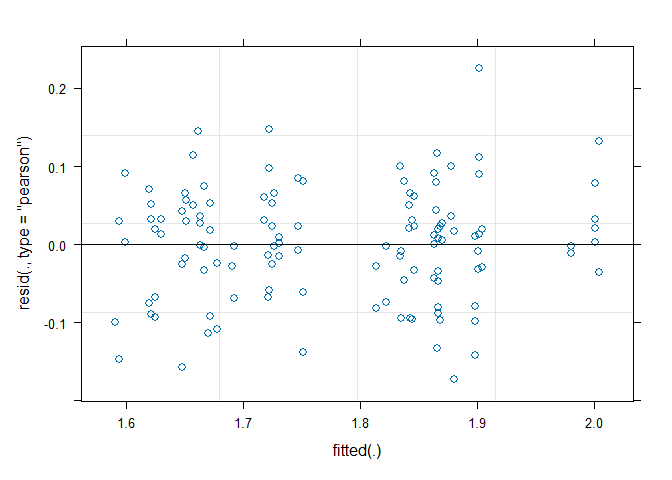

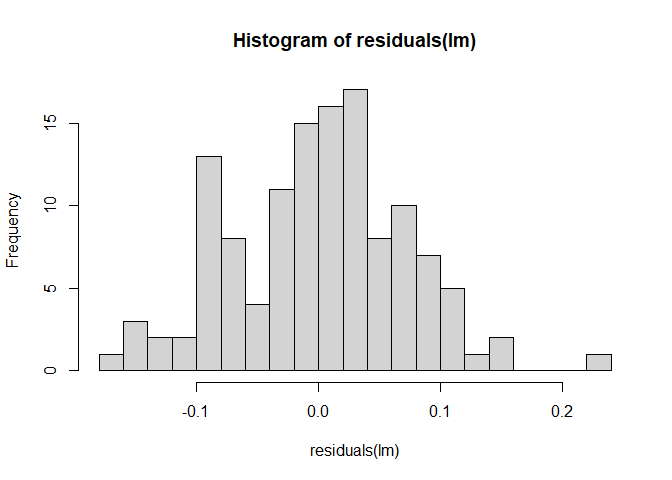

```
## [1] "the number of complete cases is 126"
```

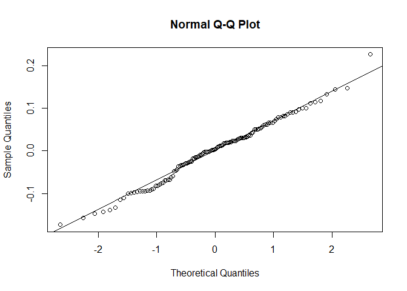

```
## Linear mixed model fit by REML. t-tests use Satterthwaite's method [
## lmerModLmerTest]
## Formula:
## trait ~ Treatment * Population + Treatment/Chamber + (1 | Population:Line)
##    Data: data
##
## REML criterion at convergence: -227.2
##
## Scaled residuals:
##      Min       1Q   Median       3Q      Max
## -2.26352 -0.58998  0.05239  0.62939  2.95373
##
## Random effects:
##  Groups          Name        Variance Std.Dev.
##  Population:Line (Intercept) 0.003144 0.05607
##  Residual                    0.005837 0.07640
## Number of obs: 126, groups:  Population:Line, 15
##
## Fixed effects:
##                             Estimate Std. Error         df t value Pr(>|t|)
## (Intercept)                 1.775477   0.016136  13.125495 110.029  < 2e-16 ***
## Treatment1                 -0.001328   0.006825 107.631481  -0.195    0.846
## Population1                -0.104374   0.016137  13.128037  -6.468 2.01e-05 ***
## Treatment1:Population1     -0.007436   0.006827 107.634625  -1.089    0.279
## TreatmentCurrent:Chamber1  -0.001567   0.009588 107.827356  -0.163    0.870
## TreatmentFuture:Chamber1   -0.010277   0.009734 107.526768  -1.056    0.293
## ---
## Signif. codes:  0 '***' 0.001 '**' 0.01 '*' 0.05 '.' 0.1 ' ' 1
##
## Correlation of Fixed Effects:
##             (Intr) Trtmn1 Ppltn1 Tr1:P1 TrC:C1
## Treatment1  -0.001
## Population1  0.067  0.006
## Trtmnt1:Pp1  0.006  0.004 -0.001
## TrtmntCr:C1 -0.005  0.000 -0.005  0.000
## TrtmntFt:C1 -0.001  0.001  0.010 -0.024  0.001
```

```
## Computing profile confidence intervals ...
```

```
##                                 2.5 %       97.5 %
## .sig01                     0.03264682  0.082698447
## .sigma                     0.06613768  0.086052435
## (Intercept)                1.74397653  1.806817834
## Treatment1                -0.01457573  0.011914978
## Population1               -0.13585151 -0.073009731
## Treatment1:Population1    -0.02066216  0.005837490
## TreatmentCurrent:Chamber1 -0.02016184  0.017049337
## TreatmentFuture:Chamber1  -0.02920492  0.008580371
```

```r
LN_bolt_anov_22 <- do_anov2(LN_bolt_lm_22)
```

```
## Type III Analysis of Variance Table with Satterthwaite's method
##                        Sum Sq  Mean Sq NumDF   DenDF F value   Pr(>F)
## Treatment            0.000575 0.000575     1 107.502  0.0985   0.7543
## Population           0.244197 0.244197     1  13.128 41.8342 2.01e-05 ***
## Treatment:Population 0.006924 0.006924     1 107.635  1.1863   0.2785
## Treatment:Chamber    0.006660 0.003330     2 107.677  0.5705   0.5669
## ---
## Signif. codes:  0 '***' 0.001 '**' 0.01 '*' 0.05 '.' 0.1 ' ' 1
```

```r
LN_bolt_anov_22$trait <- "l10_LeafNumb_bolting"
LN_bolt_emmeans_22 <- get_table_bt(LN_bolt_lm_22)
```

```
## NOTE: A nesting structure was detected in the fitted model:
##     Chamber %in% Treatment
```

```r
LN_bolt_means_22<- as.data.frame(LN_bolt_emmeans_22)
LN_bolt_pairs_22 <- as.data.frame(pairs(LN_bolt_emmeans_22))
LN_bolt_pairs_22$trait <- "l10_LeafNumb_bolting"
```

### Biomass

above ground biomass

```r
# above ground biomass (same as rosette biomass)
AG_lm_22 <- do_lmer2(Dat_2022c$l10_AG_DryBiomass)
```

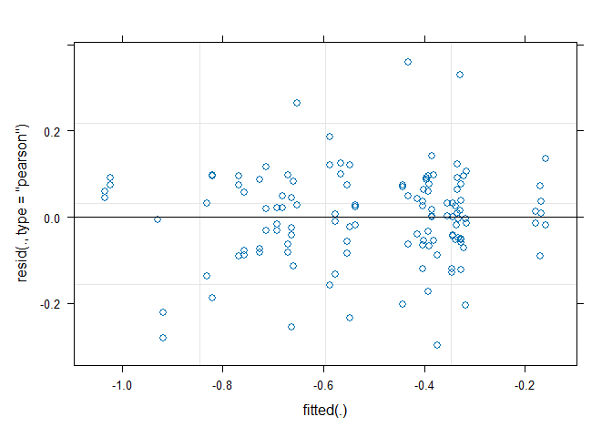

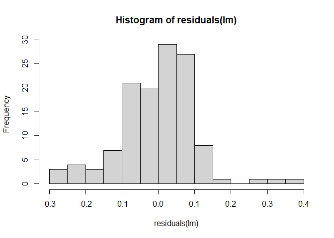

```
## [1] "the number of complete cases is 126"
```

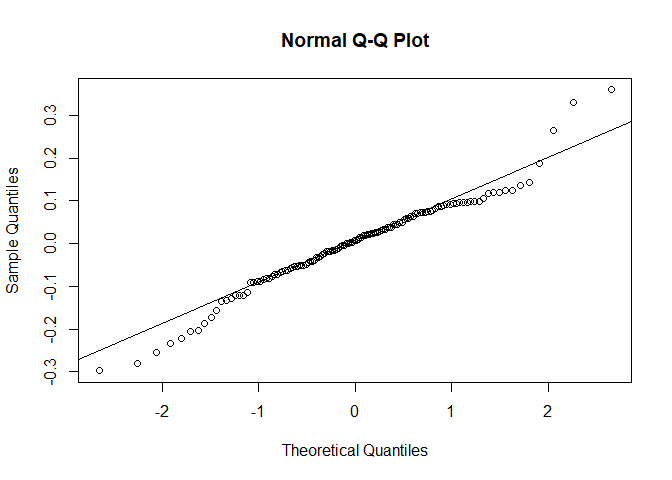

```
## Linear mixed model fit by REML. t-tests use Satterthwaite's method [
## lmerModLmerTest]
## Formula:
## trait ~ Treatment * Population + Treatment/Chamber + (1 | Population:Line)
##    Data: data
##
## REML criterion at convergence: -122.2
##
## Scaled residuals:
##      Min       1Q   Median       3Q      Max
## -2.60569 -0.50644  0.06613  0.64012  3.14732
##
## Random effects:
##  Groups          Name        Variance Std.Dev.
##  Population:Line (Intercept) 0.01505  0.1227
##  Residual                    0.01305  0.1142
## Number of obs: 126, groups:  Population:Line, 15
##
## Fixed effects:
##                             Estimate Std. Error         df t value Pr(>|t|)
## (Intercept)                -0.517617   0.033486  13.145304 -15.458 8.19e-10 ***
## Treatment1                  0.028729   0.010209 107.394867   2.814 0.005821 **
## Population1                -0.182934   0.033487  13.146602  -5.463 0.000105 ***
## Treatment1:Population1      0.023961   0.010212 107.396664   2.346 0.020796 *
## TreatmentCurrent:Chamber1  -0.005627   0.014345 107.517931  -0.392 0.695629
## TreatmentFuture:Chamber1    0.005342   0.014558 107.316324   0.367 0.714371
## ---
## Signif. codes:  0 '***' 0.001 '**' 0.01 '*' 0.05 '.' 0.1 ' ' 1
##
## Correlation of Fixed Effects:
##             (Intr) Trtmn1 Ppltn1 Tr1:P1 TrC:C1
## Treatment1   0.000
## Population1  0.068  0.006
## Trtmnt1:Pp1  0.006  0.004  0.000
## TrtmntCr:C1 -0.005  0.000 -0.005  0.000
## TrtmntFt:C1 -0.001  0.001  0.007 -0.024  0.001
```

```
## Computing profile confidence intervals ...
```

```
##                                  2.5 %      97.5 %
## .sig01                     0.077946115  0.17595216
## .sigma                     0.098885374  0.12867395
## (Intercept)               -0.582979374 -0.45255296
## Treatment1                 0.008955844  0.04858656
## Population1               -0.248299238 -0.11786997
## Treatment1:Population1     0.004180640  0.04382271
## TreatmentCurrent:Chamber1 -0.033416320  0.02226638
## TreatmentFuture:Chamber1  -0.022959470  0.03355445
```

```r
AG_anov_22 <- do_anov2(AG_lm_22)
```

```
## Type III Analysis of Variance Table with Satterthwaite's method
##                       Sum Sq Mean Sq NumDF   DenDF F value    Pr(>F)
## Treatment            0.03386 0.03386     1 107.305  2.5944 0.1101830
## Population           0.38947 0.38947     1  13.147 29.8436 0.0001045 ***
## Treatment:Population 0.07184 0.07184     1 107.397  5.5051 0.0207963 *
## Treatment:Chamber    0.00377 0.00189     2 107.417  0.1445 0.8656398
## ---
## Signif. codes:  0 '***' 0.001 '**' 0.01 '*' 0.05 '.' 0.1 ' ' 1
```

```r
AG_anov_22$trait <- "l10_Above Ground Biomass"
AG_emmeans_22 <- get_table_bt(AG_lm_22)
```

```
## NOTE: A nesting structure was detected in the fitted model:
##     Chamber %in% Treatment
```

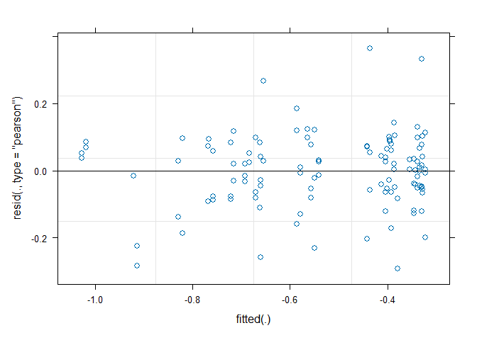

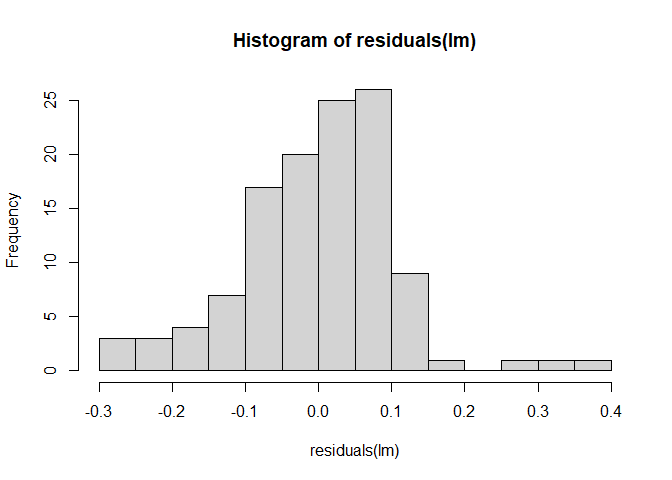

```
## [1] "the number of complete cases is 118"
```

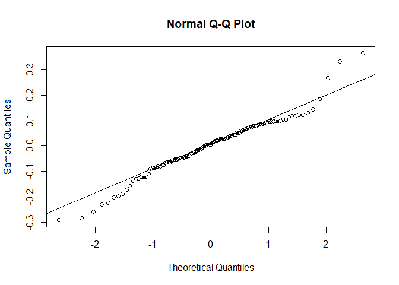

```
## Linear mixed model fit by REML. t-tests use Satterthwaite's method [
## lmerModLmerTest]
## Formula:
## trait ~ Treatment * Population + Treatment/Chamber + (1 | Population:Line)
##    Data: data
##
## REML criterion at convergence: -109.9
##
## Scaled residuals:
##     Min      1Q  Median      3Q     Max
## -2.5027 -0.4880  0.0549  0.6203  3.1209
##
## Random effects:
##  Groups          Name        Variance Std.Dev.
##  Population:Line (Intercept) 0.01318  0.1148
##  Residual                    0.01364  0.1168
## Number of obs: 118, groups:  Population:Line, 14
##
## Fixed effects:
##                             Estimate Std. Error         df t value Pr(>|t|)
## (Intercept)                -0.530579   0.032667  12.172996 -16.242 1.28e-09 ***
## Treatment1                  0.028320   0.010809 100.443206   2.620 0.010156 *
## Population1                -0.169659   0.032668  12.174621  -5.193 0.000214 ***
## Treatment1:Population1      0.024477   0.010813 100.445385   2.264 0.025738 *
## TreatmentCurrent:Chamber1  -0.003258   0.015150 100.602911  -0.215 0.830152
## TreatmentFuture:Chamber1    0.004496   0.015392 100.378657   0.292 0.770840
## ---
## Signif. codes:  0 '***' 0.001 '**' 0.01 '*' 0.05 '.' 0.1 ' ' 1
##
## Correlation of Fixed Effects:
##             (Intr) Trtmn1 Ppltn1 Tr1:P1 TrC:C1
## Treatment1  -0.001
## Population1  0.001  0.006
## Trtmnt1:Pp1  0.006 -0.064 -0.001
## TrtmntCr:C1 -0.005  0.000 -0.005  0.000
## TrtmntFt:C1 -0.001  0.003  0.008 -0.026  0.002
```

```
## Computing profile confidence intervals ...
```

```
##                                  2.5 %      97.5 %
## .sig01                     0.070600325  0.16728284
## .sigma                     0.100569502  0.13200386
## (Intercept)               -0.594327316 -0.46719361
## Treatment1                 0.007413119  0.04934388
## Population1               -0.233420210 -0.10628173
## Treatment1:Population1     0.003552322  0.04549512
## TreatmentCurrent:Chamber1 -0.032570520  0.02619272
## TreatmentFuture:Chamber1  -0.025409551  0.03429776
```

```r
AG_means_22 <- as.data.frame(AG_emmeans_22)
AG_pairs_22 <- as.data.frame(pairs(AG_emmeans_22))
AG_pairs_22$trait <- "l10_Above Ground Biomass"
## also has SQR transformation -interaction gets a little weaker
#AG_lm_22SQR <- do_lmer2(Dat_2022c$SQR_AG_DryBiomass)
#AG_anov_22SQR <- do_anov2(AG_lm_22SQR)
#AG_anov_22SQR$trait <- "SQR_Above Ground Biomass"

geno_ag_22 <- as.data.frame(get_geno_table_bt22(Dat_2022c$l10_AG_DryBiomass))
geno_ag_22$trait <- "l10_AG"

# check outliers.
AG_outliers <- do_lmer2(Dat_2022c_outliers$l10_AG_DryBiomass, data = Dat_2022c_outliers)
```

```r
do_anov2(AG_outliers)
```

```
## Type III Analysis of Variance Table with Satterthwaite's method
##                       Sum Sq Mean Sq NumDF   DenDF F value   Pr(>F)
## Treatment            0.03503 0.03503     1 100.358  2.5677 0.112207
## Population           0.36792 0.36792     1  12.175 26.9721 0.000214 ***
## Treatment:Population 0.06990 0.06990     1 100.445  5.1247 0.025738 *
## Treatment:Chamber    0.00180 0.00090     2 100.491  0.0659 0.936290
## ---
## Signif. codes:  0 '***' 0.001 '**' 0.01 '*' 0.05 '.' 0.1 ' ' 1
```

```
##                           Sum Sq      Mean Sq NumDF     DenDF     F value
## Treatment            0.035025734 0.0350257338     1 100.35761  2.56772446
## Population           0.367920133 0.3679201335     1  12.17462 26.97209799
## Treatment:Population 0.069904598 0.0699045979     1 100.44539  5.12468195
## Treatment:Chamber    0.001797125 0.0008985623     2 100.49062  0.06587329
##                           Pr(>F)  exp
## Treatment            0.112207488 2022
## Population           0.000214032 2022
## Treatment:Population 0.025738209 2022
## Treatment:Chamber    0.936289879 2022
```

below ground biomass

```r
# below ground biomass
BG_lm_22 <- do_lmer2(Dat_2022c$BG_DryBiomass)
```

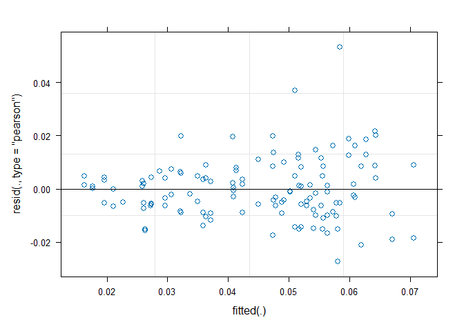

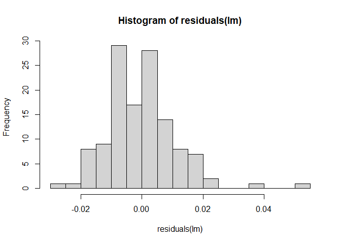

```
## [1] "the number of complete cases is 126"
```

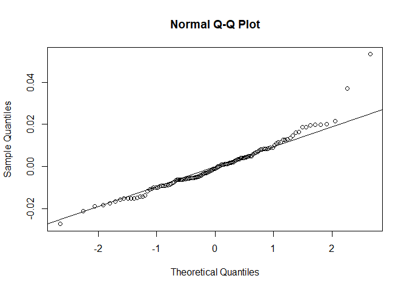

```
## Linear mixed model fit by REML. t-tests use Satterthwaite's method [
## lmerModLmerTest]
## Formula:
## trait ~ Treatment * Population + Treatment/Chamber + (1 | Population:Line)
##    Data: data
##
## REML criterion at convergence: -669.7
##
## Scaled residuals:
##     Min      1Q  Median      3Q     Max
## -2.2283 -0.5329 -0.0752  0.5097  4.3533
##
## Random effects:
##  Groups          Name        Variance  Std.Dev.
##  Population:Line (Intercept) 6.147e-05 0.00784
##  Residual                    1.497e-04 0.01223
## Number of obs: 126, groups:  Population:Line, 15
##
## Fixed effects:
##                             Estimate Std. Error         df t value Pr(>|t|)
## (Intercept)                4.438e-02  2.321e-03  1.351e+01  19.121 3.56e-11 ***
## Treatment1                 3.222e-03  1.093e-03  1.081e+02   2.949 0.003911 **
## Population1               -1.197e-02  2.321e-03  1.352e+01  -5.157 0.000163 ***
## Treatment1:Population1     5.344e-04  1.093e-03  1.081e+02   0.489 0.625830
## TreatmentCurrent:Chamber1 -1.803e-03  1.535e-03  1.083e+02  -1.175 0.242664
## TreatmentFuture:Chamber1  -7.264e-04  1.558e-03  1.080e+02  -0.466 0.642057
## ---
## Signif. codes:  0 '***' 0.001 '**' 0.01 '*' 0.05 '.' 0.1 ' ' 1
##
## Correlation of Fixed Effects:
##             (Intr) Trtmn1 Ppltn1 Tr1:P1 TrC:C1
## Treatment1  -0.002
## Population1  0.066  0.006
## Trtmnt1:Pp1  0.006  0.003 -0.002
## TrtmntCr:C1 -0.005  0.000 -0.005  0.000
## TrtmntFt:C1 -0.001  0.001  0.011 -0.024  0.001
```

```
## Computing profile confidence intervals ...
```

```
##                                  2.5 %       97.5 %
## .sig01                     0.004396843  0.011704462
## .sigma                     0.010590480  0.013770282
## (Intercept)                0.039840519  0.048877007
## Treatment1                 0.001104886  0.005344716
## Population1               -0.016503462 -0.007466530
## Treatment1:Population1    -0.001582994  0.002658058
## TreatmentCurrent:Chamber1 -0.004774944  0.001180142
## TreatmentFuture:Chamber1  -0.003757972  0.002289996
```

```r
BG_anov_22 <- do_anov2(BG_lm_22)
```

```
## Type III Analysis of Variance Table with Satterthwaite's method
##                         Sum Sq   Mean Sq NumDF   DenDF F value    Pr(>F)
## Treatment            0.0004516 0.0004516     1 107.981  3.0178 0.0852081 .
## Population           0.0039793 0.0039793     1  13.518 26.5900 0.0001629 ***
## Treatment:Population 0.0000358 0.0000358     1 108.121  0.2391 0.6258295
## Treatment:Chamber    0.0002388 0.0001194     2 108.173  0.7980 0.4528588
## ---
## Signif. codes:  0 '***' 0.001 '**' 0.01 '*' 0.05 '.' 0.1 ' ' 1
```

```r
BG_anov_22$trait <- "Below Ground Biomass"
BG_emmeans_22 <- get_table(BG_lm_22)
```

```
## NOTE: A nesting structure was detected in the fitted model:
##     Chamber %in% Treatment
```